# Getting into R

## Using functions

### The `()`s

```r
2 + 3 # infix form
[1] 5
`+`(2, 3) # prefix form, notice the backticks
[1] 5
```

The above is to explain the logic behind a simple principle in `R` programming: **If it is a function** (used in its standard *prefix* form) **then it must have** `()`**s. If it is not a function, then it must NOT have them**. If you understand this, you will never attempt to run commands like `as.factor[x]` or `my_data(...)`!

### Specifying arguments

The vast majority of functions require you to give it *at least* one argument. Arguments of a function are often named. From the point of view of a user of a function, these names are only *placeholders* for some values we want to pass to the function. In RStudio, you can type the name of a function, open the bracket and then press the Tab key to see a list of arguments the function takes. You can try it now, type, for instance, `sd(` and press the Tab key. You should see a pop-up list of two arguments – `x =` and `na.rm =` – appear.

This means, that to use the `sd()` function *explicitly*, we much give it two arguments: a `numeric` vector and a single `logical` value (technically, a `logical` vector of length 1):

```r
sd(x = c(-4, 1, 100, 52, -32, 0.5433, NA), na.rm = FALSE)
[1] NA
```

The output of the function is `NA` because our vector contained an `NA` value and the `na.rm =` argument that removes the `NA`s was set to `FALSE`. Try setting it to `TRUE` (or `T` if you’re a lazy typist) and see what `R` gives you.

Look what happens when we run the following command:

```r
sd(x = c(-4, 1, 100, 52, -32, 0.5433)) # no NAs this time
[1] 47.83839
```

We didn’t specify the value of the `na.rm =` argument but the code worked anyway. Why might that be…?

#### Default values of arguments

The reason for this behaviour is that functions can have arguments set to some value **by default** to facilitate the use of the functions in the most common situations by reducing the amount of typing. Look at the documentation for the `sd()` function (by running `?sd` in the console).

You should see that under “**Usage**” it reads `sd(x, na.rm = FALSE)`. This means that, by default, the `na.rm =` argument is set to `FALSE` and if you don’t specify its value manually, the function will run with this setting. Re-visiting our example with the `NA` value, you can see that the output is as it was before:

```r
sd(c(-4, 1, 100, 52, -32, 0.5433, NA))
[1] NA
```

#### Argument matching

You may have noticed a tiny change in the way the first argument was specified in the line above (coding is a lot about attention to detail!) – there is no `x =` in the code.

The reason why `R` is still able to understand what we meant is *argument matching*. If no names are given to the arguments, `R` assumes they are entered in the order in which they were specified when the function was created. This is the same order you can look up in the “Usage” section of the function documentation (using `?`)

To give you another example, take `rnorm()` for instance. If you pull up the documentation (AKA help) of the file with `?rnorm`, you’ll see that it takes 3 arguments: `n =`, `mean =`, and `sd =`. The latter two have default values but `n =` doesn’t so we must provide its value.

Setting the first argument to 10 and omitting the other 2 will generate a vector of 10 numbers drawn from a normal distribution with $\mu = 0$ and $\sigma=1$:

```r
rnorm(10)
 [1] -1.1214444  0.4428291  0.7238918 -0.6933037  0.2940328  0.6536408 -0.5655049  0.2199482 -1.1666868  0.3188004
```

Lets say we want to change the mean to -5 but keep standard deviation the same. Relying on argument matching, we can do:

```r
rnorm(10, -5)
 [1] -5.924322 -4.901201 -5.361008 -5.887790 -3.200888 -4.794808 -3.489609 -5.173515 -5.855457 -5.452387
```

However, if we want to change the `sd =` argument to 3 but leave `mean =` set to 0, we need to let `R` know this more explicitly. There are several ways to do the same thing but they all rely on the principle that unnamed values will be interpreted in order of arguments:

```r
rnorm(10, 0, 3) # keep mean = 0
 [1]  0.2292364  6.6194823 -0.8538996  3.5625652 -1.2232430  2.9926999 -2.9078032  2.2758753  0.2482522 -2.9068456
rnorm(10, , 3) # skip mean = (DON'T DO THIS! it's illegible)
 [1]  3.01955128 -0.65220907 -2.59786017 -4.41342734  6.45669067  4.77704205 -0.06304579  5.20348449  1.00031073
[10] -3.12143841
```

If the arguments are named, they can be entered in **any order**:

```r
rnorm(sd = 2, n = 10, mean = -100)
 [1]  -99.03286 -100.66477  -98.16179 -100.71461  -97.64191  -98.20014 -100.50212  -98.68060 -103.69662 -101.26471
```

The important point here is that if you give a function 4 (for example) *unnamed* values separated with commas, `R` **will try to match them to the first 4 arguments of the function**. If the function takes fewer than arguments or if the values are not valid for the respective arguments, `R` will throw an error:

```r
rnorm(100, 5, -3, 8) # more values than arguments
Error in rnorm(100, 5, -3, 8): unused argument (8)
```

That is, it will throw an error if you’re lucky. If you’re not, you might get all sorts of unexpected behaviours:

```r
rnorm(10, T, -7) # illegal values passed to arguments
 [1] NaN NaN NaN NaN NaN NaN NaN NaN NaN NaN
```

#### Passing vectors as arguments

The majority of functions – and you’ve already seen quite a few of these – have at least one argument that can take multiple values. The `x =` (first) argument of `sample()` or the `labels =` argument of `factor()` are examples of these.

Imagine we want to sample 10 draws with replacement from the words “elf”, “orc”, “hobbit”, and “dwarf”. Your intuition might be to write something like `sample("elf", "orc", "hobbit", "dwarf", 10)`. That will however not work:

```r
sample("elf", "orc", "hobbit", "dwarf", 10, replace = T)
Error in sample("elf", "orc", "hobbit", "dwarf", 10, replace = T): unused arguments ("dwarf", 10)
```

Take a moment to ponder why this produces an error…

So, how do we tell `R` that we want to pass the four races of Middle-earth to the first argument of `sample()`? Well, we need to bind them into a single vector using the `c()` function:

```r
sample(c("elf", "orc", "hobbit", "dwarf"), 10, T)
 [1] "orc"    "dwarf"  "dwarf"  "hobbit" "hobbit" "dwarf"  "dwarf"  "elf"    "elf"    "hobbit"
```

**Remember:** If you want to pass a vector of values into a single argument of a function, you need to use an object in your environment containing the vector or a function that outputs a vector. The basic one is `c()` but others work too, *e.g.,* `sample(5:50, 10)` (the `:` operator returns a vector containing a complete sequence of integers between the specified values).

#### Passing objects as arguments

**Everything in** `R` **is an object** and thus the values passed as arguments to functions are also objects. It is completely up to you whether you want to create the object *ad hoc* for the purpose of only passing it to a function or whether you want to pass to a function an object you already have in your environment. For example, if our four races are of particular interest to us and we want to keep them for future use, we can assign them to the environment under some name:

```r
ME_races <- c("elf", "orc", "hobbit", "dwarf")
ME_races # here they are
[1] "elf"    "orc"    "hobbit" "dwarf"
```

Then, we can just use them as arguments to functions:

```r
factor(sample(1:4, 20, T), labels = ME_races)
 [1] dwarf  orc    elf    hobbit dwarf  dwarf  hobbit hobbit dwarf  hobbit dwarf  orc    elf    elf    hobbit
[16] orc    elf    elf    hobbit hobbit
Levels: elf orc hobbit dwarf
```

## Function output

### Command is a representation of its output

#### One-way street

Another important thing to realise is that, given that there are many ways to do the same thing in `R`, there is a sort of directionality to the relationship between a command and its output. If you know what a function does, you can unambiguously tell what the output will be given specified arguments. However, once the output is produced, there is no way `R` can tell what command was used.

Imagine you have three bakers making the same kind of bread: one uses the traditional kneading method, one uses the slap-and-fold technique, and one uses a mixer. If you know the recipe and the procedure they are using, you will be able to tell what they’re making. However, once you have your three loaves in front of you, you won’t be able to say which came from which baker. It’s the same thing with commands in `R`!

This is the reason why some commands look like they’re repeating things beyond necessity. Take, for instance, this line:

```r
mat[lower.tri(mat)] <- "L"
```

The `lower.tri()` function takes a matrix as its first argument and returns a matrix of logicals with the same dimensions as the matrix provided. Once it returns its output, `R` has no way of knowing what matrix was used to produce it and so it has no clue that it has anything to do with our matrix `mat`. That’s why, if we want to modify the lower triangle of `mat`, we do it this way.

Obviously, nothing is stopping you from creating the logical matrix by means of some other approach and then use it to subset `mat` but the above solution is both more elegant and more intelligible.

### Knowe thine output as thou knowest thyself

Because more often than not you will be using function to create some object only so that you can feed it into another function, it is **essential** that you understand what you are asking `R` to do and know what result you are expecting. There should be no surprises!

A good way to practice is to say to yourself what the output of a command will be before you run it. For instance, the command `factor(sample(1:4, 20, T), labels = ME_races)` returns a *vector of class* `factor` *and length 20* containing randomly sampled values labelled according to the four races of Middle-earth we worked with.

## Output is an object

Notice that in the code above we passed the `sample(1:4, 20, T)` command as the first argument of `factor()`. This works because – as we mentioned earlier – a command is merely a symbolic representation of its output and because **everything in** `R` **is an object**. This means that function output is also an object. Depending on the particular function, the output can be anything from, *e.g.,* a logical vector of length 1 through long vectors and matrices to huge data frames and complex lists of lists of lists…

For instance, the `t.test()` function returns a list that contains all the information about the test you might ever need:

```r
t_output <- t.test(rnorm(100, 5, 2), mu = 0)
str(t_output) # see the structure of the object
List of 10
 $ statistic  : Named num 29.9
  ..- attr(*, "names")= chr "t"
 $ parameter  : Named num 99
  ..- attr(*, "names")= chr "df"
 $ p.value    : num 2.03e-51
 $ conf.int   : num [1:2] 4.77 5.45
  ..- attr(*, "conf.level")= num 0.95
 $ estimate   : Named num 5.11
  ..- attr(*, "names")= chr "mean of x"
 $ null.value : Named num 0
  ..- attr(*, "names")= chr "mean"
 $ stderr     : num 0.171
 $ alternative: chr "two.sided"
 $ method     : chr "One Sample t-test"
 $ data.name  : chr "rnorm(100, 5, 2)"
 - attr(*, "class")= chr "htest"
```

If we want to know the *p*-value of the above test, we can simply query the list accordingly:

```r
t_output$p.value
[1] 2.032262e-51
```

Because the command only represents the output object, it can be accessed in the same way. Say you are running some kind of simulation study and are only interested in the *t*-statistic of the test. Instead of saving the entire output into some kind of named object in the environment, you can simply save the *t*:

```r
t_stat <- t.test(rnorm(100, 5, 2), mu = 0)$statistic
t_stat
       t
22.89709
```

### Where does the output go?

Let’s go back to discussing `factor()`. There’s another important issue that sometime causes a level of consternation among novice `R` users. Imagine we have a data set and we want to designate one of its columns as a factor so that `R` knows that the column contains a categorical variable.

```r
df <- data.frame(id = 1:10, x = rnorm(10))
df
   id           x
1   1 -1.15439957
2   2 -0.73321657
3   3  0.86623882
4   4 -1.63544665
5   5  0.62756835
6   6 -0.63513337
7   7  0.08171012
8   8  1.38781958
9   9  0.12687800
10 10 -0.77953758
```

An intuitive way of turning `id` into a factor might be:

```r
factor(df$id)
 [1] 1  2  3  4  5  6  7  8  9  10
Levels: 1 2 3 4 5 6 7 8 9 10
```

This, however, does not work:

```r
class(df$id)
[1] "integer"
```

The reason for this has to do with the fact that the argument-output relationship is directional. Once the object inside `df$id` is passed to `factor()`, `R` forgets about the fact that it had anything to do with `df` or one of its columns. It has therefore no way of knowing that you want to be modifying a column of a data frame. Because of that, the only place `factor()` can return the output to is the one it uses by default.

#### Console

The vast majority of functions return their output into the console. `factor()` is one of these functions. That’s why when you type in the command above, you will see the printout of the output in the console. Once it’s been returned, the output is forgotten about – `R` can’t see the console or read from it!

This is why `factor(df$id)` does not turn the `id` column of `id` into a factor.

#### Environment

A small number of functions return a named object to the global `R` environment, where you can see, access, and work with it. The only one you will need to use for a *long* time to come (possibly ever) is the already familiar assignment operator `<-`.

You can use `<-` to create new objects in the environment or re-assign values to already existing names. So, if you want to turn the `id` column of `df` into a factor you need to reassign some new object to `df$id`. What object? Well, the one returned by the `factor(...)` command above:

```r
df$id <- factor(df$id)
```

As you can see, there is no printout now because the output of `factor()` has been passed into the assignment function which directed it into the `df$id` object. Let’s make sure it really worked:

```r
class(df$id)
[1] "factor"
```

#### Graphical device

Functions that create graphics return their output into something called the *graphical device*. It is basically the thing responsible for drawing stuff on the screen of your computer. You’ve already encountered some of these functions – `plot()`, `par()`, `lines()`, `abline()`.

#### Files

Of course, you can redirect where particular output gets sent, just like we did with `df$id <- factor(...)`. For instance, you can save a plot into the global environment using assignment:

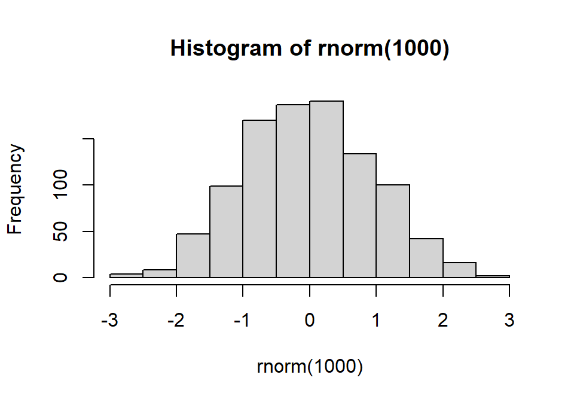

```r
my_plot <- hist(rnorm(1000))
```

```r
my_plot
$breaks
 [1] -3.0 -2.5 -2.0 -1.5 -1.0 -0.5  0.0  0.5  1.0  1.5  2.0  2.5  3.0

$counts
 [1]   4   8  47  99 170 187 191 134 100  42  16   2

$density
 [1] 0.008 0.016 0.094 0.198 0.340 0.374 0.382 0.268 0.200 0.084 0.032 0.004

$mids
 [1] -2.75 -2.25 -1.75 -1.25 -0.75 -0.25  0.25  0.75  1.25  1.75  2.25  2.75

$xname
[1] "rnorm(1000)"

$equidist
[1] TRUE

attr(,"class")
[1] "histogram"
```

Alternatively, you can export it by creating a new graphical device inside of a file:

```r
# create a graphical device in  a new my_plot.png
# file in the working directory
png("my_plot.png")
hist(rnorm(100)) # create plot
# close the graphical device
dev.off()
```

# Making the computer do the heavy lifting

## Avoiding repetition and avoiding repetition

Data manipulation and analysis often carries the burden of repetition. For instance, we might have to clean each of several many variables according to the same set of rules or repeat the same statistical test over many variables (and of course, adequately correct for multiple testing afterwards!).Every time you encounter repetitive tasks like these, you should start thinking about how to delegate as much of the legwork as possible on the computer.

This is where loops come in very handy. They are used to repeat a block of code an arbitrary number of times. Let’s look at the anatomy of a loop in `R`:

```r
for (i in n) {
# code
}
```

the `for () {}` bit is just syntax and it’s sole function is to tell `R` that this is a loop. The bit in `()` defines the iterator variable `i` and the vector `n` over which the loop iterates. So `for (i in 1:10)` will be a loop that runs through 10 times. First, it will assign `i` the value of 1 and run the rest of the code. Then, it will assign it the next value in the `n` vector, *e.g.,* 2 and run the code again. It will repeat until it runs out of elements of `n`.

To demonstrate:

```r
for (i in 1:5) {
  print(i)
}
[1] 1
[1] 2
[1] 3
[1] 4
[1] 5
```

As you can see, the loop printed the value of `i` for each of the 5 iterations.

The code in the body of the loop `{}` can do whatever you want. you can use the current value of `i` to create, modify, or subset data structures, to do calculations with it, or simply not use it at all. The world’s your oyster!

Finally, loops can be nested, if needed:

```r
for (i in n) {
  for (j in m) {
# code
  }
}
```

This will run all the iterations of the inner loop for each iteration of the outer one.

You will often want to save the output of each iteration of the loop. There are again many ways to do this but a straight-forward one is to first create an empty object and then start combining it with the output of the loop:

```r
out <- c() # empty vector
for (i in 1:10) {
# append the result of some operation to to the vector
  out <- c(out, i * 3)
}
out
 [1]  3  6  9 12 15 18 21 24 27 30
```

Let’s see how we can use loops to do something useful. Imagine we have 5 numeric variables and we want to report their correlations along with *p*-values. It would be nice to put everything in a single correlation matrix with *r* coefficients in the upper triangle and the *p*-values in the lower, like this:

```
      X1    X2    X3     X4    X5
X1 0.000 0.067 0.692  0.603 0.110
X2 0.510 0.000 0.077 -0.025 0.824
X3 0.000 0.444 0.000  0.405 0.055
X4 0.000 0.806 0.000  0.000 0.022
X5 0.276 0.000 0.585  0.825 0.000
```

Let’s say, our data are stored in an object called `cor_data` that looks like this (first 6 rows):

```r
head(cor_data)
          X1          X2         X3         X4         X5
1 -1.1449623  0.10851188 -0.1469994 -1.3378348  1.2034584
2 -1.1326783  0.07788878 -0.2129065 -0.8193853  0.8064527
3  0.6234970  1.52865188  0.9094090 -0.5174297  1.1725049
4 -0.6215550  0.44813878  0.7883387  0.5475085  0.3661103
5  1.6117073 -0.58492750  0.8135219  0.4825858 -0.4577348
6  0.3431764 -0.57591902  1.7077745 -0.3941463 -0.4317633
```

Getting the correlation coefficients is simple, we can just use `R`’s `cor()` function:

```r
cor(cor_data)
           X1          X2         X3          X4         X5
X1 1.00000000  0.06659087 0.69202065  0.60319452 0.11005479
X2 0.06659087  1.00000000 0.07747677 -0.02482107 0.82441930
X3 0.69202065  0.07747677 1.00000000  0.40491845 0.05532656
X4 0.60319452 -0.02482107 0.40491845  1.00000000 0.02232820
X5 0.11005479  0.82441930 0.05532656  0.02232820 1.00000000
```

As you can see, the matrix is symmetrical along its diagonal: the upper triangle is the same as the lower one. What we want to do now is to replace the elements of the lower triangle with the *p*-values corresponding to the correlation coefficients. To get the *p*-value for a correlation of two variables, we can use the `cor.test()` function:

```r
cor.test(cor_data$X1, cor_data$X2)

    Pearson's product-moment correlation

data:  cor_data$X1 and cor_data$X2
t = 0.66068, df = 98, p-value = 0.5104
alternative hypothesis: true correlation is not equal to 0
95 percent confidence interval:
 -0.1315478  0.2596133
sample estimates:
       cor
0.06659087
```

The output of this function is a list and we can use `$` to isolate the *p*-value:

```r
cor.test(cor_data$X1, cor_data$X2)$p.value
[1] 0.5103661
```

So what we need now is a loop that takes each pair of variables one at a time, gets the *p*-value from the `cor.test()` function and puts it the correct place in the correlation matrix. For this, we need a nested loop, with one level defining the first of the pair of variables to correlate and the other defining the second:

```r
cmat <- cor(cor_data) # stores correlation matrix in an object

for (i in 1:ncol(cor_data)) { # i goes from 1 to the number of variables in data - 5
  for (j in i:ncol(cor_data)) { #  j goes from i to number of vars in data
    cmat[j, i] <- # jth row of ith column of cmat will be replaced with...
      cor.test(cor_data[ , i], # cor.test p-value for ith variable...
               cor_data[ , j])$p.value  # ...and jth variable
  }
}

# let's see what cmat looks like now, rounded to 3 decimal places
round(cmat, 3)
      X1    X2    X3     X4    X5
X1 0.000 0.067 0.692  0.603 0.110
X2 0.510 0.000 0.077 -0.025 0.824
X3 0.000 0.444 0.000  0.405 0.055
X4 0.000 0.806 0.000  0.000 0.022
X5 0.276 0.000 0.585  0.825 0.000
```

At this stage, this might not seem like an easy task but, with a little practice and dedication, you can learn how to use loops to save yourself a lot of time and effort!

## The `apply()` family

Another way of telling `R` to do a repetitive task is using the `apply()` family functions. These function take some data structure and apply any function to each element of that structure.

To illustrate, let’s look at `apply()`. Imagine we have a data frame `df` like this:

```
  id          X1          X2         X3         X4         X5
1  1 -1.12868477 -0.70136367  2.4727407  0.3038149  2.3081217
2  2  0.85798449  1.15102340 -0.6927555  1.2604438 -0.2528562
3  3  1.62555437  0.19027978 -0.5944153 -0.9140631  0.7463609
4  4  0.81100584 -0.03046336  0.3911101 -0.9521716  1.5840948
5  5 -0.53555625  3.03003518  1.1071856 -0.3287793  0.2816084
6  6 -0.09918767 -1.31432288 -1.2443535  1.8449483 -1.7249673
```

Let’s say we want to know which of the `X1`-`X5` columns contains the largest value *for each participant*. If we only take the first row, for example, then the task is easy, right?

```r
df[1, 2:6]
         X1         X2       X3        X4       X5
1 -1.128685 -0.7013637 2.472741 0.3038149 2.308122
which.max(df[1, 2:6])
X3
 3
```

If we want to know this bit of information for every row of the data frame, doing it manually is quite tedious. We *could* instead use a `for` loop:

```r
max_col <- c()
for (i in 1:nrow(df)) max_col <- c(max_col, which.max(df[i, 2:6]))
max_col
X3 X4 X1 X5 X2 X4 X3 X3 X3 X4 X2 X3 X1 X1 X1 X5 X3 X5 X5 X3
 3  4  1  5  2  4  3  3  3  4  2  3  1  1  1  5  3  5  5  3
```

This loop iterates over the rows of `df` (`for (i in 1:nrow(df))`) and for each cycle it adds the output of the `which.max()` function to the `max_col` variable.

There is nothing wrong with this approach but it is a little wordy to write and not the fastest when it comes to computation time. The `apply()` function can be used to achieve the same outcome faster and using less code:

```r
max_col2 <- apply(X = df[ , 2:6], MARGIN = 1, FUN = which.max)
max_col2
 [1] 3 4 1 5 2 4 3 3 3 4 2 3 1 1 1 5 3 5 5 3
all(max_col == max_col2) # result is the same
[1] TRUE
```

So how does this work? `apply()` requires 3 arguments: - `X` – a matrix (remember that data frames can be treated as matrices) - `MARGIN` – `1` for by row, `2` for by column - `FUN` – name of function to apply (notice no `()`s)

Other arguments can be provided, for example `na.rm = T` if the function applied takes the `na.rm =` argument (*e.g.,* `mean()`).

The function takes the matrix provided to the `X =` argument and applies the function passed to `FUN =` along the margin (rows/columns) of the matrix, specified by the `MARGIN =` argument.

This is useful, don’t you think? The function becomes even more useful when you realise you can apply your own functions (more on writing functions later). Let’s say, we want to know the standard error estimate based on the 5 values for each participant:

```r
# define function (std error = sd / sqrt(n))
std.error <- function(x, na.rm) sd(x, na.rm = na.rm)/sqrt(length(na.omit(x)))

apply(df[ , 2:6], 1, std.error, na.rm = T) # na.rm value will get passed on to std.error
 [1] 0.7477130 0.3945574 0.4583920 0.4229087 0.6463091 0.6471814 0.3526739 0.4435087 0.5180623 0.3121514 0.3259463
[12] 0.4161781 0.5682815 0.3265633 0.3606750 0.5079722 0.2928740 0.6205303 0.2095644 0.3259012
```

You don’t even have to create a function object!

```r
# same thing, different way
apply(df[ , 2:6], 1,
      function(x) sd(x, na.rm = T)/sqrt(length(na.omit(x))))
 [1] 0.7477130 0.3945574 0.4583920 0.4229087 0.6463091 0.6471814 0.3526739 0.4435087 0.5180623 0.3121514 0.3259463
[12] 0.4161781 0.5682815 0.3265633 0.3606750 0.5079722 0.2928740 0.6205303 0.2095644 0.3259012
```

To give another example, this is how you can calculate the standard deviation of each of the `X` **columns** of `df`.

```r
apply(df[ , 2:6], 2, sd, na.rm = T)
       X1        X2        X3        X4        X5
0.9334217 1.0419721 1.1418232 0.8479441 1.2435062
```

There are quite a few functions in the `apply()` family (*e.g.,* `vapply()`, `tapply()`, `mapply()`, `sapply()`), each doing something slightly different and each appropriate for a different data structure (`vector`, `matrix`, `list`, `data.frame`) and different task. You can read about all of them, if you want but we’d like to tell you about one in particular – `lapply()`

The `lapply()` function takes a `list` (list apply) and applies a function to each of its elements. The function returns a list. This function is useful because data frames can also be treated as lists. This is what you do every time you use the `$` operator.

```r
lapply(df[ , 2:6], sd, na.rm = T)
$X1
[1] 0.9334217

$X2
[1] 1.041972

$X3
[1] 1.141823

$X4
[1] 0.8479441

$X5
[1] 1.243506
```

If you don’t want the output to be a list, just use `unlist()`:

```r
unlist(lapply(df[ , 2:6], sd, na.rm = T))
       X1        X2        X3        X4        X5
0.9334217 1.0419721 1.1418232 0.8479441 1.2435062
```

Say we want to round all the `X` columns to 2 decimal places. That means, that we want to assign to columns 2-6 of `df` values corresponding to rounded versions of the same columns:

```r
df[ , 2:6] <- lapply(df[ , 2:6], round, 2)
head(df)
  id    X1    X2    X3    X4    X5
1  1 -1.13 -0.70  2.47  0.30  2.31
2  2  0.86  1.15 -0.69  1.26 -0.25
3  3  1.63  0.19 -0.59 -0.91  0.75
4  4  0.81 -0.03  0.39 -0.95  1.58
5  5 -0.54  3.03  1.11 -0.33  0.28
6  6 -0.10 -1.31 -1.24  1.84 -1.72
```

So these are the two most useful functions from the `apply()` family you should know. As a general tip, you can use `apply()` for by-row operations and `lapply()` for by-column operations on data frames. The nice thing about these function is that they help you avoid repetitive code. For instance, you can now turn several columns of your data set into factors using something like `df[ , c(2, 5, 7, 8)] <- lapply(df[ , c(2, 5, 7, 8)], factor)`. Cool, innit?

## Conditional code evaluation

### `if`

The idea is pretty simple – sometimes you want some code to run under certain circumstances but not under others. This is what conditional code evaluation is for and this is what it looks like:

```r
if (condition) {
  code
}
```

The (not actual) code above is how you tell `R` to run whatever code *if and only if* the condition is met. It then follows that whatever the condition is, it must evaluate to a single boolean (`TRUE`/`FALSE`):

```r
cond <- TRUE

if (cond) {
  print(paste0("Condition was ", cond, ", so code is evaluated."))
}
print("Next line of code...")
[1] "Condition was TRUE, so code is evaluated."
[1] "Next line of code..."
```

If we change `cond` to `FALSE`, the code in the curly braces will be skipped:

```r
cond <- FALSE

if (cond) {
  print(paste("Condition was", cond, ", so code is evaluated."))
}
print("Next line of code...")
[1] "Next line of code..."
```

Pretty straight-forward, right?

OK, now, the condition can be whatever logical operation that returns a single boolean, not just `TRUE` or `FALSE`. Here’s an example of something more useful:

```r
x <- rnorm(100)
x[sample(100, 2)] <- NA # introduce 2 NAs in random places

if (any(is.na(x))) {
  print("There are missing values in x")
}
print("Next line of code...")
[1] "There are missing values in x"
[1] "Next line of code..."
```

Here, the `x` vector is checked for `NA` values using `is.na()`. The function, however, returns one boolean *per element of* `x` and not just a single `T`/`F`. The `any()` function checks the returned vector of logicals and if there are any `T`s, returns `TRUE` and if not, returns `FALSE`.

It might also be reasonable to have different chunks of code you want to run, one if condition is met, the other if it isn’t. You *could* do it with multiple `if` statements:

```r
x <- rnorm(100)

if (any(is.na(x))) {
  print("There are missing values in x")
}
if (!any(is.na(x))) { # if there are no NAs
  print("There are NO missing values in x")
}
print("Next line of code...")
[1] "There are NO missing values in x"
[1] "Next line of code..."
```

It is a bit cumbersome though, don’t you think?

### `else`

Luckily, there’s a better way of doing the same thing – the `else` statement:

```r
x <- rnorm(100)

if (any(is.na(x))) {
  print("There are missing values in x")
} else { # if there are no NAs
  print("There are NO missing values in x")
}
print("Next line of code...")
[1] "There are NO missing values in x"
[1] "Next line of code..."
```

Here, if the `any(is.na(x))` condition evaluates to `TRUE`, the first line of code is run and the second one is skipped. If it’s `FALSE`, the code in the `else` clause will be the one that gets run.

So, if there are only two outcomes of the test inside the condition clause that we want to run contingent code for, `if () {} else {}` is the syntax to use. Bear in mind, however, that sometimes, there might be more than two meaningful outcomes. Look at the following example:

```r
x <- "blue"

if (x == "blue") {
  print(paste("Her eyes were", x))
} else {
  print(paste("Her eyes were not blue, they were", x))
}
print("Next line of code...")
[1] "Her eyes were blue"
[1] "Next line of code..."
```

### `else if`

You should now be able to understand the following code without much help:

```r
x <- "green"

if (x == "blue") {
  print(paste("Her eyes were", x))
} else if (x == "brown") {
  print(paste("As is the case with most people, her eyes were", x))
} else if (x %in% c("green", "grey")) {
  print(paste("She was one of those rare people whose eyes were", x))
}
print("Next line of code...")
[1] "She was one of those rare people whose eyes were green"
[1] "Next line of code..."
```

If you feel like it, you can put the code above inside a `for` loop, assigning `x` values of `"blue"`, `"brown"`, `"grey"`, `"green"`, and – let’s say – `"long"`, one at a time and see the output.

```r
for (x in c("blue", "brown", "grey", "green", "long")) {
  if (x == "blue") {
    print(paste("Her eyes were", x))
  } else if (x == "brown") {
    print(paste("As is the case with most people, her eyes were", x))
  } else if (x %in% c("green", "grey")) {
    print(paste("She was one of those rare people whose eyes were", x))
  }
  print("Next line of code...")
}
[1] "Her eyes were blue"
[1] "Next line of code..."
[1] "As is the case with most people, her eyes were brown"
[1] "Next line of code..."
[1] "She was one of those rare people whose eyes were grey"
[1] "Next line of code..."
[1] "She was one of those rare people whose eyes were green"
[1] "Next line of code..."
[1] "Next line of code..."
```

The point the example above is aiming to get across is that, when using `else`, you need to make sure that the code after the clause is appropriate for all all possible scenarios, where the condition in `if` is `FALSE`.

### `ifelse()`

In situations, where you are happy that there are indeed only two sets of outcomes of your condition, you can use the shorthand function `ifelse()`. Take a look at the following code example:

```r
apples <- data.frame(
  colour = c("green", "green", "red", "red", "green"),
  taste = c(4.3, 3.5, 3.9, 2.7, 6.4)
)

apples$redness <- ifelse(apples$colour == "red", 1, 0)

apples$redness
[1] 0 0 1 1 0
```

What is happening here? In this command, a new variable is being created in the `apples` data frame called `redness`. To decide what value to give each case (row) for this variable, an `ifelse` statement is used. For each row in the data, the value of the `redness` variable is based on the value of the `colour` variable. When `colour` is red, the value for `redness` is `1`, for any other value of `colour` - `redness`; will be `0`.

`ifelse()` has the following general formulation:

```r
ifelse(condition,
       value to return if TRUE,
       value to return if FALSE)
```

As you might see, a nice advantage of `ifelse()` over `if () {} else {}` is that it is *vectorised*, meaning it will evaluate for every element of the vector in condition. On the flip side, `ifelse()` can only return a single object, while the code inside `if () {} else {}` can be arbitrarily long and complex. For that reason, `ifelse()` is best for **simple conditional assignment** (*e.g.,* `x <- ifelse(...)`), while `if () {} else {}` is used for more complex conditional branching of your code. As with many other things in programming (and statistics), it’s a case of [horses for courses](https://en.wiktionary.org/wiki/horses_for_courses)…

To consolidate this, let’s look at the data frame again:

```r
head(apples)
  colour taste redness
1  green   4.3       0
2  green   3.5       0
3    red   3.9       1
4    red   2.7       1
5  green   6.4       0
```

For the first two rows, the condition evaluates to `FALSE` because the first two values in the `colour` variable are not `"red"`. Therefore, the first two elements of our outcome (the new variable `redness`) are set to `0`. The next two values in the `colour` variable were `"red"` so, for these elements, the condition evaluated to `TRUE` and thus the next two values of `redness` were set to `1`.

### Nesting clauses

The level of conditional evaluation shown above should give you the necessary tools for most conditional tasks. However, if you’re one of those people who like to do really complicated things, then **a)** what are you doing with your life? and **b)** bear in mind `if`, `else`, and `ifelse()` can be combined and nested to an arbitrary level of complexity:

```r
# not actual code!
if (cond_1) {
  if (cond_1_1) {
    ...
  } else if (cond_1_2) {
    ...
  } else {
    x <- ifelse(cond_1_3_1, ..., ...)
  }
} else (cond_2) {
  x <- ifelse(cond_2_1,
         ifelse(cond_2_1_1, ..., ...),
         ...)
} ...
```

Same rules apply. If you’re brave (or foolhardy) enough to get into this kind of programming, then please make sure all your opening and closing brackets and curly braces are paired up in the right place, otherwise fixing your code will be a right bag of giggles!

## Writing your own functions

Admittedly, this section about user-defined functions is a little bit advanced. However, the ability to write your own functions is an immensely powerful tool for data processing and analysis so you are encouraged to put some effort into understanding how functions work and how you can write your own. It’s really not difficult!

### Functions are objects too!

It’s probably getting a bit old at this stage but **everything in** `R` **is an object**. And since functions are a subset of everything, they also are objects. They are essentially chunks of code stored into a named object that sits in some environment. User-defined functions will be located in the global environment, while functions from packages (either pre-loaded ones or those you load using `library()`) sit in the environments of their respective packages.

If you want to see the code inside a function, just type it into the console without the brackets and press Enter. You might remember this chap:

```r
lower.tri
function (x, diag = FALSE)
{
    d <- dim(x)
    if (length(d) != 2L)
        d <- dim(as.matrix(x))
    if (diag)
        .row(d) >= .col(d)
    else .row(d) > .col(d)
}
<bytecode: 0x000001dc78418e00>
<environment: namespace:base>
```

### Anatomy of a function

Looking at the code above you can see the basic structure of a function:

- First, it’s specified that this object is a `function`
- Second, in the `()`s, there’s the specifications of the argument the function takes including any default values
  - As you can see `lower.tri()` takes two arguments, `x` and `diag`, the latter of which is set by default to `FALSE`
- Third, there is the body of the function enveloped in a set of *curly braces* `{}` which includes the actual code that does the function’s magic
- Finally, there is some meta-information including the environment in which the function lives (in this case, it’s the `"base"` package)

Notice that the function code only works using the `x` and `diag` objects. No matter what you pass to the function’s `x` argument will – as far as the function is concerned – be called `x`. That is why `R` doesn’t know where the value passed to the arguments of functions come from!

### DIY

To make your own function, all you need to do is follow the syntax above, come up with your own code, and assign the function object to a name in your global `R` environment:

```r
my_fun <- function(arg1, arg2, arg3, ...) {
  some code using args
  return(object to return)
}
```

The `return()` function is not strictly speaking necessary but it’s good practice to be explicit about this of the many potential objects inside of the function’s environment you want to return to the global environment.

Let’s start with something simple. Let’s write a function that takes as its only argument a person’s name and returns a greeting:

```r
hello <- function(name) {
  out <- paste0("Hello ", name, "!")
  return(out)
}
```

So, we created a named object `hello` and assigned it a function of one argument `name =`. Inside the `{}`s, there is code that creates and object `out` with a character string created from pasting together `"Hello "`, whatever gets passed to the `name =` argument, and an exclamation point. Finally, this `out` gets returned into the global environment.

Let’s see if it works:

```r
hello("Tim")
[1] "Hello Tim!"
```

Nice. Not extremely useful, but nice…

Let’s create a handier function. One thing that is sometimes done when cleaning data is removing outlying values. Wouldn’t it be useful to have a function that does it for us? (Aye, it would!)

Basic boxplots are quite a good way of identifying outliers. Let’s demonstrate this:

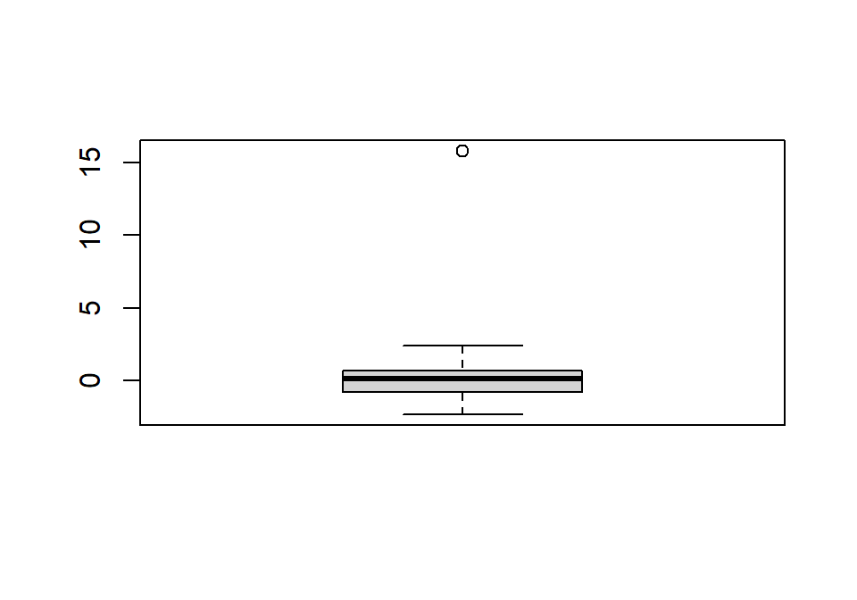

```r
x <- rnorm(100)
x[82] <- 15.82 # add a large number
boxplot(x)
```

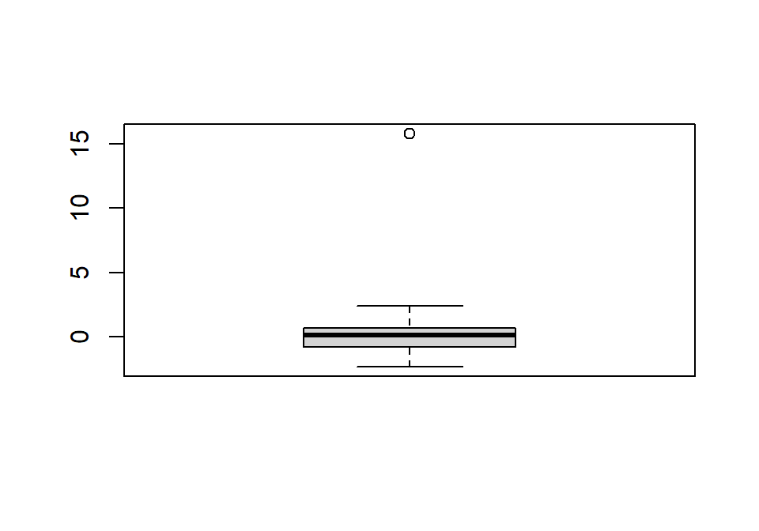

```r
bxplt <- boxplot(x)
```

```r
str(bxplt)
List of 6
 $ stats: num [1:5, 1] -2.319 -0.763 0.147 0.711 2.383
 $ n    : num 100
 $ conf : num [1:2, 1] -0.0854 0.3803
 $ out  : num 15.8
 $ group: num 1
 $ names: chr "1"
```

The `str()` function shows us the structure of the `boxplot()` output object. On inspection, you can see that the `$out` element of the list returned by the function includes the outlying values. The one we imputed manually (15.82) is there, which is a good sanity check. Let’s extract only these values:

```r
outl <- boxplot(x, plot = F)$out # don't show plot
outl
[1] 15.82
```

Cool, all we need to do now is replace the values of `x` that are equal to these values with `NA`s:

```r
x %in% outl
  [1] FALSE FALSE FALSE FALSE FALSE FALSE FALSE FALSE FALSE FALSE FALSE FALSE FALSE FALSE FALSE FALSE FALSE FALSE
 [19] FALSE FALSE FALSE FALSE FALSE FALSE FALSE FALSE FALSE FALSE FALSE FALSE FALSE FALSE FALSE FALSE FALSE FALSE
 [37] FALSE FALSE FALSE FALSE FALSE FALSE FALSE FALSE FALSE FALSE FALSE FALSE FALSE FALSE FALSE FALSE FALSE FALSE
 [55] FALSE FALSE FALSE FALSE FALSE FALSE FALSE FALSE FALSE FALSE FALSE FALSE FALSE FALSE FALSE FALSE FALSE FALSE
 [73] FALSE FALSE FALSE FALSE FALSE FALSE FALSE FALSE FALSE  TRUE FALSE FALSE FALSE FALSE FALSE FALSE FALSE FALSE
 [91] FALSE FALSE FALSE FALSE FALSE FALSE FALSE FALSE FALSE FALSE

x[x %in% outl] <- NA
```

We can now look at `x` to see that the outlying values have been replaced with `NA`s:

```r
x
  [1]  0.79263416  0.77165479 -0.29000096  0.98369404  0.14487923  0.16110103  1.39352737  0.58608767  2.16505840
 [10]  0.13964347 -1.29197704 -2.18416061 -0.31463376 -1.09647417  0.21680322 -0.89125726  0.74655740  0.01412954
 [19]  1.08543143  0.77058668 -0.41935906  1.25085110  0.56434020  0.99216625 -0.85876034 -0.39687017  0.52509905
 [28] -0.56568239  0.29478571  0.87348391 -0.96470847 -1.16240304 -0.96545199 -0.78623379 -2.11421014 -1.27634553
 [37] -2.31858616  0.15037172  1.95174971 -0.38361818  1.28050808  1.64106289  0.67958128  0.04397382  0.74290935
 [46]  0.82827460  0.39736039  0.19552528  0.15006744  0.60007641 -0.92835089 -0.30400667 -0.76670669 -1.73723575
 [55]  0.25646797 -0.94119583  1.62933537 -0.24085538 -0.63658868  0.62741300 -0.70993956 -0.22738118 -1.75652740
 [64] -0.37152836  1.07093301  1.68815026 -0.35042868  0.77626689  0.37063869  0.62069482  1.38759977  0.65570750
 [73] -0.75846128 -0.45574367  0.36519472  0.49459089 -1.39695288 -1.49320187 -0.06542406  1.04008267  0.33718311
 [82]          NA -0.75488190 -2.05739487 -1.35507760  0.21631846  0.57547365  1.07866865 -2.24132915  0.19991358
 [91] -0.68125914  0.37158413  0.27640134 -0.27194546 -0.76655707 -0.47043167 -2.29543398  0.09525634 -2.19345266
[100]  2.38320866
```

```r
out.liar <- function(variable) { # arguments can be called whatever
  remove <- boxplot(variable, plot = F)$out
  variable[variable %in% remove] <- NA
  return(variable)
}
```

Let’s try it out!

```r
x <- rnorm(20, 9, 2)
x[2] <- 1520
x
 [1]    9.136746 1520.000000    4.511991    6.334016    5.668011    4.577907   11.785375    8.754681    9.601476
[10]   10.891010   10.429534    6.437277   10.306455   10.283721   11.083182    7.704050   10.276806    4.523781
[19]    5.175645    9.813580
```

```r
x <- out.liar(x)
x
 [1]  9.136746        NA  4.511991  6.334016  5.668011  4.577907 11.785375  8.754681  9.601476 10.891010 10.429534
[12]  6.437277 10.306455 10.283721 11.083182  7.704050 10.276806  4.523781  5.175645  9.813580
```

Pretty neat, huh?

The code inside of the function definition can be as simple or as complicated as you want it to be. However, it must run without errors and you need to think about various edge cases that might break the code or lead to unexpected behaviour. For instance, if we give out `out.liar()` function a character vector, it will throw an error because `boxplot()` can only cope with numeric vectors:

```r
out.liar(letters)
Error in x[floor(d)] + x[ceiling(d)]: non-numeric argument to binary operator
```

This error message is a little obscure but what happened is that `out.liar()` passed the vector of letters to `boxplot()` which, in turn, passed it to the `+` function. Since you cannot add letters, the function threw an error, thus breaking `boxplot()` and `out.liar()`.

You might also wish to make the function able to identify outliers in a data frame. To do that you would have to make the function recognise which columns of the data frame provided are numeric and then run the code on each one of these columns. Finally the function should return the entire data frame with the non-numeric columns untouched and the numeric ones modified:

```r
out.liar <- function(variable) { # arguments can be called whatever
  if (class(variable) == "data.frame") {
# identify numeric variables by applying the is.numeric
# function to each column of the data frame
    num_vars <- unlist(lapply(variable, is.numeric))
# run the out.liar function on each numeric column
# this kind of recurrence where you run a function inside of itself
# is allowed and often used!
    variable[num_vars] <- lapply(variable[num_vars], out.liar)
  } else {
    remove <- boxplot(variable, plot = F)$out
    variable[variable %in% remove] <- NA
  }
  return(variable)
}
```

Let’s see if it works. First, create some data frame with a couple of outlying values:

```r
df <- data.frame(id = factor(1:10), var1 = c(100, rnorm(9)),
                 var2 = c(rchisq(9, 4), 100), var3 = LETTERS[1:10])
df
   id        var1        var2 var3
1   1 100.0000000   2.3370628    A
2   2  -1.6867183   1.0846125    B
3   3  -0.8394512   5.4908450    C
4   4  -0.1697719   6.5114239    D
5   5   0.8447611  14.3561662    E
6   6  -0.9725008   2.9369055    F
7   7   1.4205198   5.3386562    G
8   8   0.7152586   0.9840219    H
9   9  -0.9514133   6.8550978    I
10 10   0.8425502 100.0000000    J
```

Next, feed `df` to `out.liar()`:

```r
out.liar(df)
   id       var1      var2 var3
1   1         NA 2.3370628    A
2   2 -1.6867183 1.0846125    B
3   3 -0.8394512 5.4908450    C
4   4 -0.1697719 6.5114239    D
5   5  0.8447611        NA    E
6   6 -0.9725008 2.9369055    F
7   7  1.4205198 5.3386562    G
8   8  0.7152586 0.9840219    H
9   9 -0.9514133 6.8550978    I
10 10  0.8425502        NA    J
```

Finally, check if the function still works on single columns even after our modification:

```r
x <- rnorm(20, 9, 2)
x[2] <- 1520
out.liar(x)
 [1] 10.213974        NA  8.382115  8.969704 11.975865  8.962351 11.362066  7.605036 11.296386  9.753150 11.604426
[12]  4.420238  8.299236  8.975516  6.242833  8.303596 10.189409  9.688305  5.674038 11.097713
```

Everything looking good!

So this is how you write functions. The principle is simple but actually creating good and safe functions requires a lot of thinking and attention to detail.

#### Hacking

Finally, if you’re really into the nitty-gritty of `R`, a great way of learning how to write functions is to look at ones you use and try to pick them apart, break them, fix them, and put them back together.

Since – sing along – **everything in** `R` **is an object**, you can assign the code inside of an already existing function to some other object. For instance, the `boxplot()` function calls a different “method” based on what input you give it (this is rather advanced programming so don’t worry too much about it!). The one we used is called `botplot.default()` and it hides deep inside package `"graphics"`. To get it out, we need to tell `R` to get it from there using the `package:::function` syntax:

```r
box2 <- graphics:::boxplot.default
box2
function (x, ..., range = 1.5, width = NULL, varwidth = FALSE,
    notch = FALSE, outline = TRUE, names, plot = TRUE, border = par("fg"),
    col = "lightgray", log = "", pars = list(boxwex = 0.8, staplewex = 0.5,
        outwex = 0.5), ann = !add, horizontal = FALSE, add = FALSE,
    at = NULL)
{
    args <- list(x, ...)
    namedargs <- if (!is.null(attributes(args)$names))
        attributes(args)$names != ""
    else rep_len(FALSE, length(args))
    groups <- if (is.list(x))
        x
    else args[!namedargs]
    if (0L == (n <- length(groups)))
        stop("invalid first argument")
    if (length(class(groups)))
        groups <- unclass(groups)
    if (!missing(names))
        attr(groups, "names") <- names
    else {
        if (is.null(attr(groups, "names")))
            attr(groups, "names") <- 1L:n
        names <- attr(groups, "names")
    }
    cls <- vapply(groups, function(x) class(x)[1L], "")
    cl <- if (all(cls == cls[1L]))
        cls[1L]
    for (i in 1L:n) groups[i] <- list(boxplot.stats(unclass(groups[[i]]),
        range))
    stats <- matrix(0, nrow = 5L, ncol = n)
    conf <- matrix(0, nrow = 2L, ncol = n)
    ng <- out <- group <- numeric(0L)
    ct <- 1
    for (i in groups) {
        stats[, ct] <- i$stats
        conf[, ct] <- i$conf
        ng <- c(ng, i$n)
        if ((lo <- length(i$out))) {
            out <- c(out, i$out)
            group <- c(group, rep.int(ct, lo))
        }
        ct <- ct + 1
    }
    if (length(cl) && cl != "numeric")
        oldClass(stats) <- cl
    z <- list(stats = stats, n = ng, conf = conf, out = out,
        group = group, names = names)
    if (plot) {
        if (is.null(pars$boxfill) && is.null(args$boxfill))
            pars$boxfill <- col
        do.call("bxp", c(list(z, notch = notch, width = width,
            varwidth = varwidth, log = log, border = border,
            pars = pars, outline = outline, horizontal = horizontal,
            add = add, ann = ann, at = at), args[namedargs]))
        invisible(z)
    }
    else z
}
<bytecode: 0x000001dc852003c0>
<environment: namespace:graphics>
```

This is the code that creates the boxplot and, if you wish, you can try to look into it and find how the function identifies outliers. You can even change the function by typing `edit(box2)`.

Being able to peer under the hood of readymade functions opens up an infinite playground for you so enjoy yourself!

# Reshaping Data

Data have a nasty habit of coming to us in a rather messy state, meaning that they do not conform to the three principles of [tidy data](https://cran.r-project.org/web/packages/tidyr/vignettes/tidy-data.html):

1. Each variable must have its own column.
2. Each observation must have its own row.
3. Each value must have its own cell.

This is what tidy data look like in practice:

| id | age | condition | time | rating |
| --- | --- | --- | --- | --- |
| 1 | 21 | A | 1 | 8 |
| 1 | 21 | A | 2 | 9 |
| 1 | 21 | B | 1 | 7 |
| 1 | 21 | B | 2 | 6 |
| 2 | 26 | A | 1 | 7 |
| 2 | 26 | A | 2 | 11 |
| 2 | 26 | B | 1 | 7 |
| 2 | 26 | B | 2 | 5 |
| 3 | 28 | A | 1 | 6 |
| 3 | 28 | A | 2 | 8 |

But more often than not, we get something delightful, such as:

| id | age | conditionA_1 | conditionA_2 | conditionB_1 | conditionB_2 |
| --- | --- | --- | --- | --- | --- |
| 1 | 21 | 8 | 9 | 7 | 6 |
| 2 | 26 | 7 | 11 | 7 | 5 |
| 3 | 28 | 6 | 8 | 9 | 9 |
| 4 | 18 | 6 | 7 | 8 | 7 |
| 5 | 26 | 5 | 8 | 7 | 9 |

As you can see, this format breaks the first 2 rules of tidy data: Each of the `condition...` columns contains several pieces of information about the values in the given column and there are multiple observations of the same variable (`"rating"` in the tidy format) per row. That is really not optimal.

Luckily `R`, and more specifically the `tidyverse`, provides tools to (relatively) easily turn messy data into tidy data. Relatively, because data can sometimes be so messy that it just takes a while and a bit of effort to get it in shape. Rest assured, however, that the difference in time and effort between tidying data in `R` on the one hand and Excel or SPSS on the other is exponential. The example above is not too horrendous but let’s start with something easier anyway.

If you want to follow along, here is the code that creates the messy data:

```r
set.seed(1234)
df_mess <- tibble(id = 1:30, age = round(rnorm(30, 25, 3)),
                  conditionA_1 = round(rnorm(30, 7, 1)),
                  conditionA_2 = round(rnorm(30, 8, 1.2)),
                  conditionB_1 = round(rnorm(30, 7, .9)),
                  conditionB_2 = round(rnorm(30, 6, 1.7))
)
```

Setting random seed with `set.seed()` ensures you will get the same “randomly” generated numbers from the `rnorm()` (random normal) functions.

## Tidyverse

As the name suggests, tidyverse is a bit of a parallel universe to base `R`. It is still `R` and all the functions tidyverse encompasses can be used the “normal” way but they come to their full strength when used with the tidyverse syntax. So yes, tidyverse is still the `R` language but it’s a dialect within the language that’s somewhat different to base `R`.

The main difference between base `R` and tidyverse is that while the former reads “inside-out”, the latter presents a pipeline of operations that flows from left to right.

What do we mean by “inside-out” Let’s look at this base `R` code:

```r
# base R - inside out
round(mean(rnorm(100)), 3)
[1] 0.109
```

Here, we generated 100 random standard normal numbers, took their mean, and rounded it to 3 decimal places. The first function is the innermost one and the sequence proceed outwards. Here is the same thing written the tidyverse way:

```r
# tidyverse - left to right
rnorm(100) %>% mean() %>% round(3)
[1] 0.109
```

Here, the sequence goes from left to right. The pipe operator `%>%` takes the output of whatever is to the left of it and pushes it to the function to the right of it **as its first argument**. `rnorm(100) %>% mean()` is thus the same as `mean(rnorm(100))`. So we first took the output of `rnorm(100)` and pushed it to the `mean()` function as its first argument. Then took the output of this step and pushed it to the `round()` function, again as its first argument, and, as we wanted to round to 3 decimal places, we specified the second argument of `round()` to be `3`.

Pipes are quite useful when your manipulation of **a single object** involves a sequence of several steps where none of the intermediate steps is particularly useful to you. They make the code legible in a way that many find more intuitive than the inside-out way base `R` works.

Apart from this principle, tidyverse includes several packages that were written with a uniform approach to data processing and visualisation in mind. Some of these packages are `ggplot2`, `tidyr`, `dplyr`, `tibble`. The latter introduces an additional data structure called `tibble` that is a kind of `data.frame+` and the former presents an alternative approach to graphics in `R`.

You can install the entire suite as a single package, aptly named `"tidyverse"` using the `install.packages("tidyverse")` command. Just remember you also need to load the package if you want to use the functions therein! (for more information, see the [tidyverse website](https://www.tidyverse.org/))

## “Wide to long”

OK, first of all, let’s simplify the data. Let’s just say we only have a single condition with two observations per participant:

```r
df_simple <- df_mess %>%
  dplyr::select(-contains("B")) %>% # get rid of columns containing B in their name
  rename(time_1 = conditionA_1, time_2 = conditionA_2) # rename "condition..." variables to "time_"
```

And here’s what we get when we print out `df_simple`.

| id | age | time_1 | time_2 |
| --- | --- | --- | --- |
| 1 | 21 | 8 | 9 |
| 2 | 26 | 7 | 11 |
| 3 | 28 | 6 | 8 |
| 4 | 18 | 6 | 7 |
| 5 | 26 | 5 | 8 |

What we want here is a data set in the long format with rows in columns `id` and `age` duplicated for each `time`. We also want an identifying `time` column with values 1 and 2 and a single `rating` column with the observations. We want this:

| id | age | time | rating |
| --- | --- | --- | --- |
| 1 | 21 | 1 | 8 |
| 1 | 21 | 2 | 9 |
| 2 | 26 | 1 | 7 |
| 2 | 26 | 2 | 11 |
| 3 | 28 | 1 | 6 |
| 3 | 28 | 2 | 8 |
| 4 | 18 | 1 | 6 |
| 4 | 18 | 2 | 7 |
| 5 | 26 | 1 | 5 |
| 5 | 26 | 2 | 8 |

In its minimal form, the `pivot_longer()` function requires 4 arguments:

- `data=`, if we’re using the `%>%` pipe, this gets taken care of
  - `cols=`, columns we want to work with, the rest will get duplicated as needed
  - `names_to=`, name of the variable we want to construct from **names of columns** in `cols=`
  - `values_to=`, name of the variable we want to construct from **values** in `cols=`

Let’s try the minimal example to see what the function does:

```r
df_simple %>%
  pivot_longer(cols = c("time_1", "time_2"),
               names_to = "time",
               values_to = "rating") %>%
  head(10) # only show first 10 rows to save space
# A tibble: 10 x 4
      id   age time   rating
   <int> <dbl> <chr>   <dbl>
 1     1    21 time_1      8
 2     1    21 time_2      9
 3     2    26 time_1      7
 4     2    26 time_2     11
 5     3    28 time_1      6
 6     3    28 time_2      8
 7     4    18 time_1      6
 8     4    18 time_2      7
 9     5    26 time_1      5
10     5    26 time_2      8
```

So we took the `time_1` and `time_2` columns and transformed them into a `time` and `rating` columns. The values in the other variables (*i.e.,* `id` and `age`) got duplicated as appropriate. The result is, however, not quite what we wanted. To turn the `time` variable into something more workable, we could use any one of several functions `R` provides for recoding variables or string replacement. We can also use the additional `names_prefix=` argument of `pivot_longer()` to tell `R` that the `"time_"` string is merely a prefix and does not contain information about the value. And while we’re at it, we can change the cumbersome `c("time_1", "time_2")` to `contains("time")`. This way, we can have an arbitrary number of `time_` columns and not worry about typing them all out:

```r
df_simple %>%
  pivot_longer(cols = contains("time"),
               names_to = "time", names_prefix = "time_",
               values_to = "rating") %>%
  head(10)
# A tibble: 10 x 4
      id   age time  rating
   <int> <dbl> <chr>  <dbl>
 1     1    21 1          8
 2     1    21 2          9
 3     2    26 1          7
 4     2    26 2         11
 5     3    28 1          6
 6     3    28 2          8
 7     4    18 1          6
 8     4    18 2          7
 9     5    26 1          5
10     5    26 2          8
```

One last thing: As you can see the class of the `time` column is `"character"` (`<chr>`). We can use the `names_transform=` argument to change it (and any other column) to something else, say `"integer"`. The argument requires a list containing a name = function pairs of variables we want to manipulate:

```r
df_long <- df_simple %>%
  pivot_longer(cols = contains("time"),
               names_to = "time",
               names_prefix = "time_",
               values_to = "rating",
               names_transform = list(
                 time = as.integer
               ))
head(df_long, 10)
# A tibble: 10 x 4
      id   age  time rating
   <int> <dbl> <int>  <dbl>
 1     1    21     1      8
 2     1    21     2      9
 3     2    26     1      7
 4     2    26     2     11
 5     3    28     1      6
 6     3    28     2      8
 7     4    18     1      6
 8     4    18     2      7
 9     5    26     1      5
10     5    26     2      8
```

Great, the variable is not of class `"numeric"` (type `"double"`):

```r
class(df_long$time)
[1] "integer"
typeof(df_long$time)
[1] "integer"
```

If this is a little confusing, just know that there are two types of numeric variables: integer and double. An integer can only hold a whole number, while a double can have a number of decimal places. It is called double because it requires twice as much computer memory to be stored (same number of digits on either side of the decimal point). So if you can be absolutely certain that your variable will only ever include integers and if you care about memory (*i.e.,* you have *really* big datasets), it may be better to use `as.integer` rather than `as.numeric` (no brackets here after function name!).

So yeah, that’s the basic wide-to-long transformation in `R`.

But what if our data are a bit messier, just like our original data set:

| id | age | conditionA_1 | conditionA_2 | conditionB_1 | conditionB_2 |
| --- | --- | --- | --- | --- | --- |
| 1 | 21 | 8 | 9 | 7 | 6 |
| 2 | 26 | 7 | 11 | 7 | 5 |
| 3 | 28 | 6 | 8 | 9 | 9 |
| 4 | 18 | 6 | 7 | 8 | 7 |
| 5 | 26 | 5 | 8 | 7 | 9 |

Here, we’re in a situation where we need to combine four columns of values into one but we also need two identifier variables, one for condition and one for measurement occasion.

> `names_to` Can be a character vector, creating multiple columns, if `names_sep` or `names_pattern` is provided.

This means that we can pass `c("condition", "time")` to the `names_to=` argument but if we do that, we have to specify one of the two arguments mentioned above. As the `names_sep=` argument is both appropriate for our data and easier to explain, let’s work with that. All we need to do is tell `R` what character separates condition from measurement occasion. In our case, this is the underscore, "_":

```r
df_mess %>%
  pivot_longer(cols = starts_with("cond"),
               names_to = c("condition", "time"),
               names_sep = "_",
               values_to = "rating") %>%
  head(10)
# A tibble: 10 x 5
      id   age condition  time  rating
   <int> <dbl> <chr>      <chr>  <dbl>
 1     1    21 conditionA 1          8
 2     1    21 conditionA 2          9
 3     1    21 conditionB 1          7
 4     1    21 conditionB 2          6
 5     2    26 conditionA 1          7
 6     2    26 conditionA 2         11
 7     2    26 conditionB 1          7
 8     2    26 conditionB 2          5
 9     3    28 conditionA 1          6
10     3    28 conditionA 2          8
```

Cool, we basically got what we wanted: two identifier variables and a single value variable. From here, we can just repeat what we did in our previous example. First, let’s get rid of the “condition” prefix using the `names_prefix=` argument:

```r
df_mess %>%
  pivot_longer(cols = starts_with("cond"),
               names_to = c("condition", "time"),
               names_sep = "_",
               names_prefix = "condition",
               values_to = "rating") %>% head(10)
# A tibble: 10 x 5
      id   age condition time  rating
   <int> <dbl> <chr>     <chr>  <dbl>
 1     1    21 A         1          8
 2     1    21 A         2          9
 3     1    21 B         1          7
 4     1    21 B         2          6
 5     2    26 A         1          7
 6     2    26 A         2         11
 7     2    26 B         1          7
 8     2    26 B         2          5
 9     3    28 A         1          6
10     3    28 A         2          8
```

And second, let’s use the `names_transform=` argument to set appropriate classes to our variables. Instead of just printing out the result, let’s save it into `df_long`:

```r
df_long <- df_mess %>%
  pivot_longer(cols = starts_with("cond"),
               names_to = c("condition", "time"),
               names_sep = "_",
               names_prefix = "condition",
               values_to = "rating",
               names_transform = list(
                 id = as.factor,
                 age = as.integer,
                 condition = as.factor,
                 time = as.integer,
                 rating = as.integer
               ))

head(df_long, 10)
# A tibble: 10 x 5
      id   age condition  time rating
   <int> <dbl> <fct>     <int>  <dbl>
 1     1    21 A             1      8
 2     1    21 A             2      9
 3     1    21 B             1      7
 4     1    21 B             2      6
 5     2    26 A             1      7
 6     2    26 A             2     11
 7     2    26 B             1      7
 8     2    26 B             2      5
 9     3    28 A             1      6
10     3    28 A             2      8
```

Et voilà!

Just in case you are wondering about the `names_pattern=` argument, let’s very briefly talk about it. It is great but it is not trivially easy to use. The reason for that is that it uses so called [“regular expressions”](https://stat.ethz.ch/R-manual/R-devel/library/base/html/regex.html) (or regex). This is a very powerful tool for manipulating strings. It can be used with many `R` functions, one of which is general string substitugion `gsub()`. Let’s see…

### Whistle-stop tour of Regex

Imagine we have these six character strings:

```r
x <- c("conditionA_1", "conditionA_2", "condition_Atime_1", "A_1", "conditionA_time1", "conditionA_12")
x
[1] "conditionA_1"      "conditionA_2"      "condition_Atime_1" "A_1"               "conditionA_time1"
[6] "conditionA_12"
```

Our task is to only exatract the capital lettr and the number. This is what `gsub()` is for. It can substitute any part of a string for any string (including empty string, `""`).

```r
s <- "I love R"
s
[1] "I love R"
# replace "love" with "feel ..." in object s
s <- gsub("love", "feel very much meh about", s)
s
[1] "I feel very much meh about R"
```

We can use `gsub()` to get rid of `"condition"` from our `x`:

```r
gsub("condition", "", x)
[1] "A_1"      "A_2"      "_Atime_1" "A_1"      "A_time1"  "A_12"
```

OK, the examples above do not involve any regex. They simply use strings to replace strings. What regex allows us to do is provide more general patterns for string extraction/replacement.

```r
x
[1] "conditionA_1"      "conditionA_2"      "condition_Atime_1" "A_1"               "conditionA_time1"
[6] "conditionA_12"
gsub("[a-z]*_?(.).*?(\\d+)", "\\1 \\2", x)
[1] "A 1"  "A 2"  "A 1"  "A 1"  "A 1"  "A 12"
```

This is of course not intelligible at all if you don’t understand regex. Explaining what the two weird strings mean is not the purpose of this section. Basically, it is saying:

"There will be some number of characters from small a to small z (including none!), then there *might* be a _. After that, remember the next single character, whatever it is. Then, there will be an arbitrary number of other non-digit characters after which remember one or more digits. Got it? OK then, only keep the two things I asked you to remember separated by a space. Thank you!"

You are not expected to understand this. The point is to show you that, as long as there is some discernible pattern in your strings, you can use regex to extract the relevant bits.

This is all very nice but how can we use it in `pivot_longer()`? Well, let’s go back to our original variable names:

```r
names(df_mess)
[1] "id"           "age"          "conditionA_1" "conditionA_2" "conditionB_1" "conditionB_2"
```

Our pattern here can, for instance, be “the word condition, then a single character to remember, followed by an underscore and, finally a single character to remember.” In regex this translates to:

```r
gsub("condition(.)_(.)", "\\1 \\2", names(df_mess))
[1] "id"  "age" "A 1" "A 2" "B 1" "B 2"
```

We could make the pattern more specific or more general but this does the job well (it also kinda looks cute with its googly eyes). So let’s just feed the pattern to the `names_patter=` argument of `pivot_longer()`:

```r
df_mess %>%
  pivot_longer(cols = starts_with("cond"),
               names_to = c("condition", "time"),
               names_pattern = "condition(.)_(.)",
               values_to = "rating") %>%
  head(10)
# A tibble: 10 x 5
      id   age condition time  rating
   <int> <dbl> <chr>     <chr>  <dbl>
 1     1    21 A         1          8
 2     1    21 A         2          9
 3     1    21 B         1          7
 4     1    21 B         2          6
 5     2    26 A         1          7
 6     2    26 A         2         11
 7     2    26 B         1          7
 8     2    26 B         2          5
 9     3    28 A         1          6
10     3    28 A         2          8
```

Because we gave two column names to the `names_to=` argument, the function knows that whatever is in the first set of brackets in `names_patter=` belongs in the first column (`"condition"`) and the stuff in the second set of brackets belongs in the second column (`"time"`). And thus we don’t need the `names_prefix=` or `names_sep=` arguments at all. Cool, isn’t it?

Now that our data are tidy, we can – for instance – run a mixed-effect model analysing the effect of condition×time on rating:

```r
library(lme4)

m1 <- lmer(rating ~ condition * time + (1 | id), df_long)

anova(m1)
Analysis of Variance Table
               npar Sum Sq Mean Sq F value
condition         1 16.133  16.133 11.9151
time              1  4.033   4.033  2.9788
condition:time    1 56.033  56.033 41.3829

summary(m1)
Linear mixed model fit by REML ['lmerMod']
Formula: rating ~ condition * time + (1 | id)
   Data: df_long

REML criterion at convergence: 389.3

Scaled residuals:
    Min      1Q  Median      3Q     Max
-2.6233 -0.4833 -0.1575  0.5043  2.3942

Random effects:
 Groups   Name        Variance Std.Dev.
 id       (Intercept) 0.1615   0.4019
 Residual             1.3540   1.1636
Number of obs: 120, groups:  id, 30

Fixed effects:
                Estimate Std. Error t value
(Intercept)       4.7667     0.4807   9.916
conditionB        3.3667     0.6718   5.011
time              1.7333     0.3004   5.769
conditionB:time  -2.7333     0.4249  -6.433

Correlation of Fixed Effects:
            (Intr) cndtnB time
conditionB  -0.699
time        -0.938  0.671
conditnB:tm  0.663 -0.949 -0.707
```

This neatly demonstrates an important point when working with `R` - **Once the data are in shape, fitting the right model is a piece of cake!**

There is quite a bit more that the `pivot_longer()` function and its `pivot_wider()` counterpart can do. If you want to read up on this, check out [this post](https://tidyr.tidyverse.org/articles/pivot.html)

## Descriptives in tidyverse

Another neat feature of tidyverse is its arsenal of functions for data description and summary statistics by groups. The logic is pretty straightforward and it chimes with the overarching philosophy of tidyverse pipelines. Two functions in particular are very useful and work very well together: `group_by() %>% summarise()`.

`group_by` is pretty self-explanatory – it groups the data by levels of a given variable or combinations of variables. On its own it doesn’t do anything else and its action is not even visible but using it is the first step to getting descriptive statistics by factor(s).

`summarise()` should follow `group_by` in the pipeline. It is used to create summary data frame (well, actually a tibble) with specified variables. For instance, if we want get the mean `rating` per each `time` point from our long-format `df` from the beginning of this lab sheet, we would just push it into `%>% group_by(time) %>% summarise(mean_rating = mean(rating))`. We can even create several summary variables, each with its own statistic. We don’t even need `df` to be in the long format. Instead, we can just extend our pipeline from earlier on like this:

```r
df_long %>%
  group_by(time) %>%
  summarise(n = n(),
            mean_rating = mean(rating))
# A tibble: 2 x 3
   time     n mean_rating
  <int> <int>       <dbl>
1     1    60        6.82
2     2    60        7.18
```

Pretty neat, huh?

As mentioned above, the output is a tibble (augmented data frame) and can be kept for later by storing it in an `R` object. Objects like the one you’ve just created can be used for creating pretty fancy plots.

# Data visualisation

One of `R`’s main strengths is undoubtedly its wide arsenal of data visualisation functions. There are multiple packages dedicated to all sorts of visualisation techniques, from basic plots, to complex graphs, maps, and animations. Arguably the most popular package in psychology and data science is `ggplot2` (gg stands for “grammar of graphics”) we’ve already briefly mentioned. It is a part of the `tidyverse` suite so once you’ve installed and loaded that, you don’t need to worry about `ggplot2`.

## `qplot()`

`ggplot2` provides two main plotting functions: `qplot()` for quick plots useful for data exploration and `ggplot()` for fully customisable publication-quality plots. Let’s first look at `qplot()`

This is basically a `ggplot2` alternative to base `R`’s general purpose plotting function `plot()`. When you use it, it will try to guess what kind of plot you likely want based on the type of data you provide. If we give it a single numeric vector (or column), we will get a histogram:

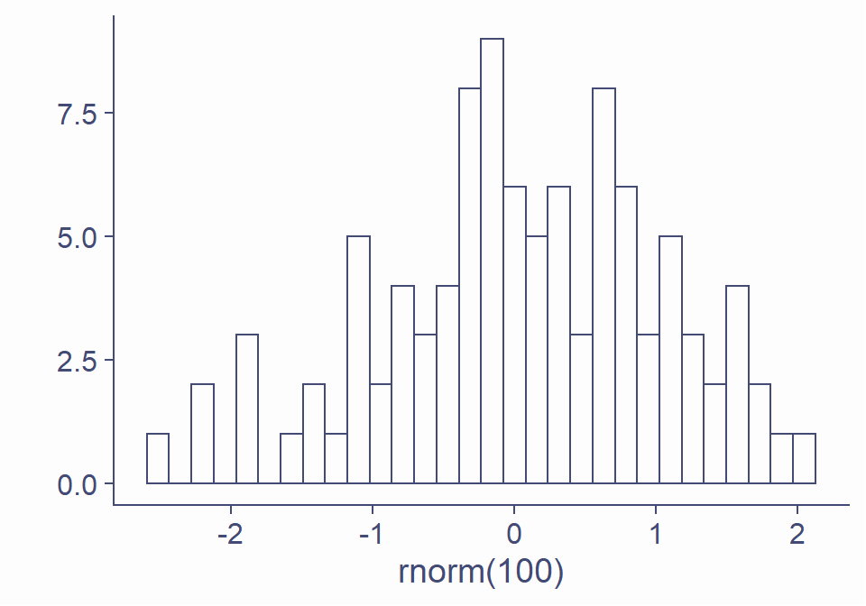

```r
qplot(rnorm(100))
```

If we give it a categorical variable (character vector or factor), it will give us a bar chart:

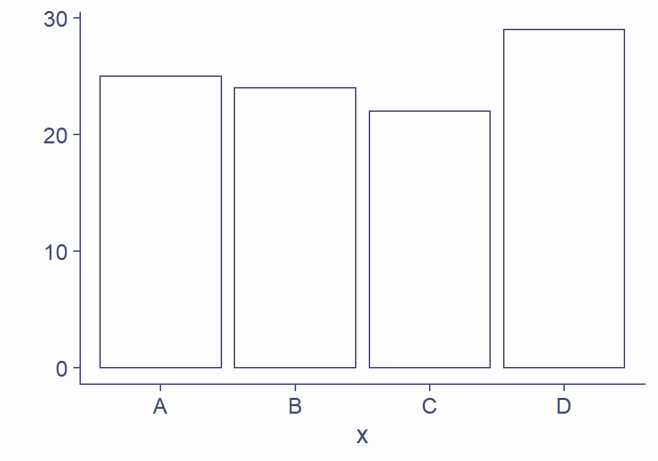

```r
x <- sample(LETTERS[1:4], 100, replace = T)
x
  [1] "C" "A" "D" "D" "A" "C" "D" "D" "A" "C" "A" "C" "A" "A" "A" "A" "B" "D" "D" "D" "A" "B" "D" "D" "B" "C" "D"
 [28] "B" "C" "D" "B" "B" "B" "C" "B" "B" "A" "D" "D" "C" "D" "D" "B" "C" "A" "D" "A" "C" "D" "C" "B" "A" "A" "B"
 [55] "D" "A" "B" "B" "B" "D" "B" "C" "B" "A" "C" "A" "C" "A" "B" "C" "D" "C" "B" "A" "D" "D" "D" "A" "A" "D" "D"
 [82] "B" "A" "D" "C" "B" "B" "C" "C" "C" "C" "A" "A" "D" "D" "A" "B" "B" "D" "C"

qplot(x)
```

Two continuous variables will produce a scatterplot:

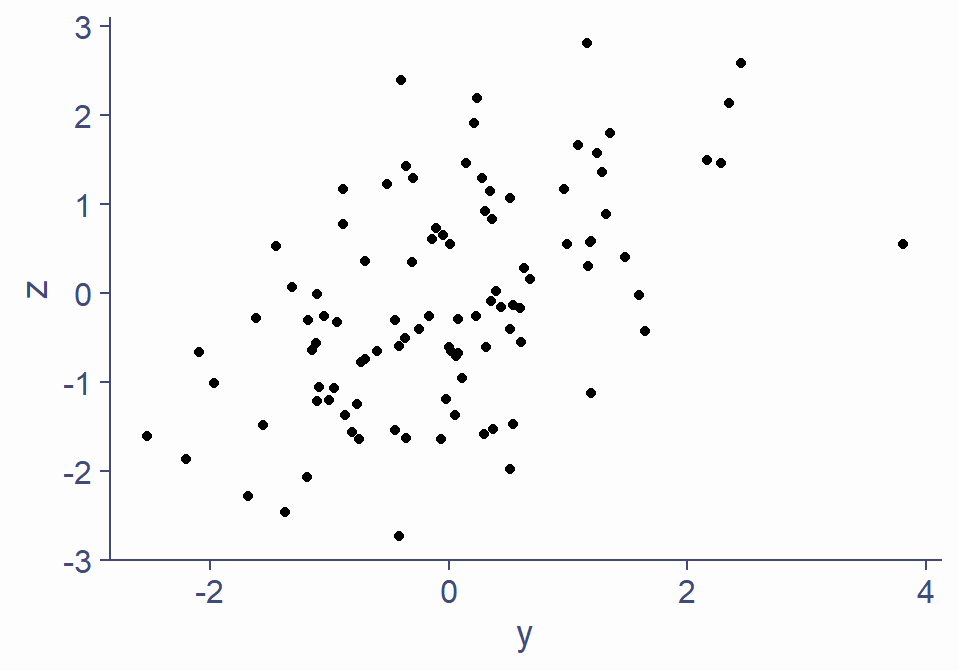

```r
y <- rnorm(100)
z <- .7 * y + rnorm(100) # two correlated variables

qplot(y, z)
```

The function takes many arguments that can be used to customise the plots and select what type of plot to display (see `?qplot` for details). The `geom =` argument specifies which plotting element (geom) to use. For instance, if we want a boxplot of a continuous variable by categorical variable, we can do:

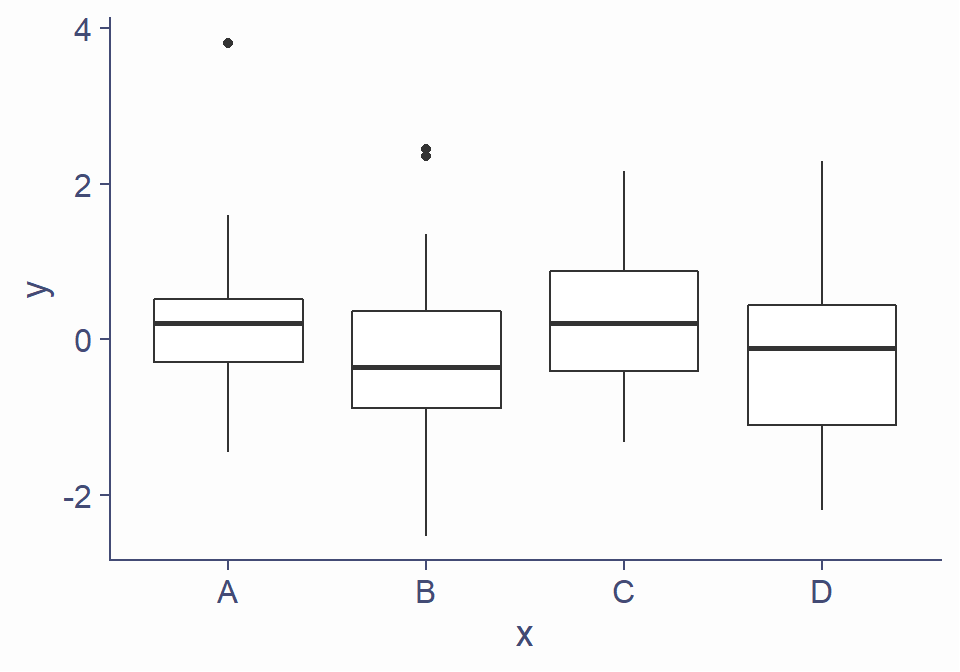

```r
qplot(x, y, geom = "boxplot")
```

We can specify several geoms in a single `qplot`. For example, we may want to overlay a regression line over our scatterplot. To do this, we need to tell `qplot()` to use both geom point and geom smooth. Moreover, we want to specify that the method for the smoother (the function that draws the line) is the linear model “lm”. (Try omitting the `method =` argument and see what happens)

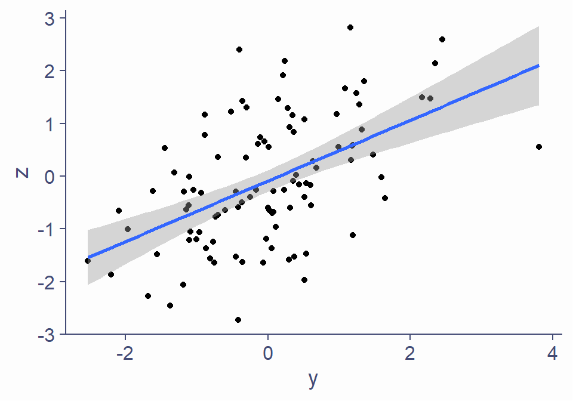

```r
qplot(y, z, geom = c("point", "smooth"), method = "lm")
```

You can actually do quite a bit more with just `qplot()` but the main workhorse of the package is the `ggplot()` function.

## `ggplot()`

Unlike `qplot()`, plots with `ggplot()` are constructed in a layered fashion. The bottom layer constructs the plotting space to which you then add layers of geoms, legends, axes, and what not. Let’s use our `df_long` data set from earlier to illustrate this system of layers.

To refresh your memory, this is what the first 6 rows of the data set look like:

```r
head(df_long)
# A tibble: 6 x 5
     id   age condition  time rating
  <int> <dbl> <fct>     <int>  <dbl>
1     1    21 A             1      8
2     1    21 A             2      9
3     1    21 B             1      7
4     1    21 B             2      6
5     2    26 A             1      7
6     2    26 A             2     11
```

Let’s start with a simple histogram of the `rating` variable:

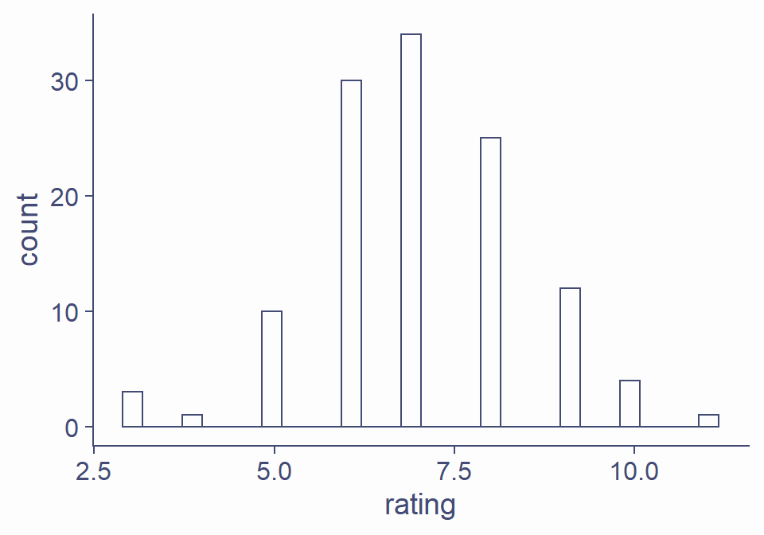

```r
ggplot(df_long, aes(rating)) +
  geom_histogram()
```

First, we used the `ggplot()` function to define the plotting space. We told it to work with `df_long` and map the `rating` variable as the only “aesthetic”. In `ggplot2` jargon, any variable that’s supposed to be responsive to various plotting functions needs to be defined as an aesthetic, inside the `aes()` function. The second layer tells `ggplot()` to add a histogram based on the variable in `aes()`, *i.e.,* `rating`.

Similarly to `qplot()`, we can create a scatterplot by mapping 2 variables to `aes()` and choosing `geom_point()` as the second layer:

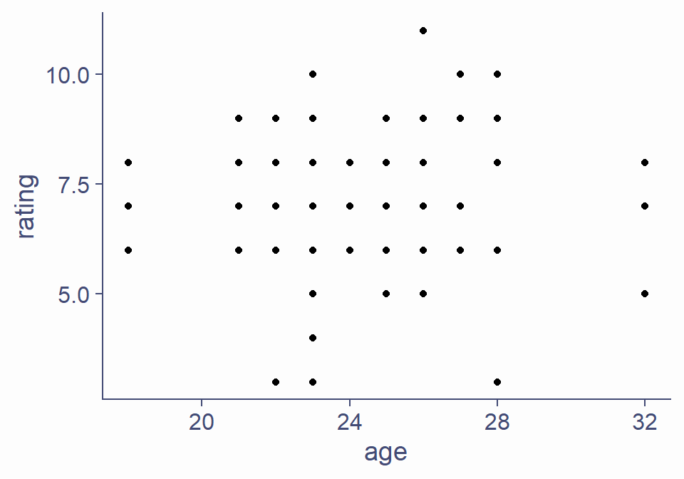

```r
ggplot(df_long, aes(age, rating)) +
  geom_point()
```

Do we want to change the colour, size, or shape of the points? No problem:

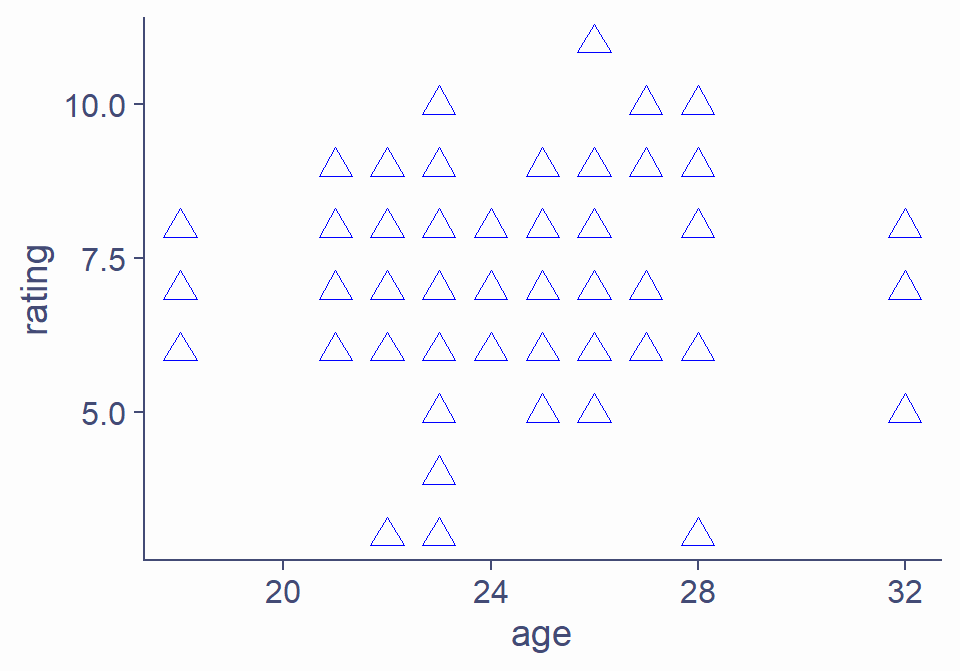

```r
ggplot(df_long, aes(age, rating)) +
  geom_point(colour = "blue", size = 4, pch = 2)
```

What if you want to colour the points by measurement `time` To do this, we need to specify colour as an aesthetic mapping it to the desired variable:

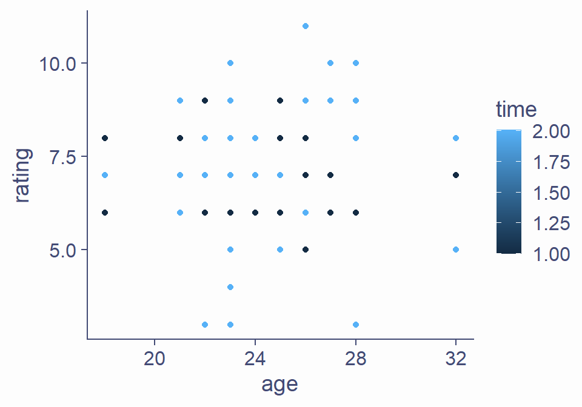

```r
ggplot(df_long, aes(age, rating)) +
  geom_point(aes(colour = time))
```

Now, because `time` is a numeric variable, `ggplot()` thinks it makes most sense to create a continuous colour scale for different values of the variable. However, that is not what we want: We only have two measurement occasions and so two distinct colours are much better. To get what we want, we need to turn `time` into a factor:

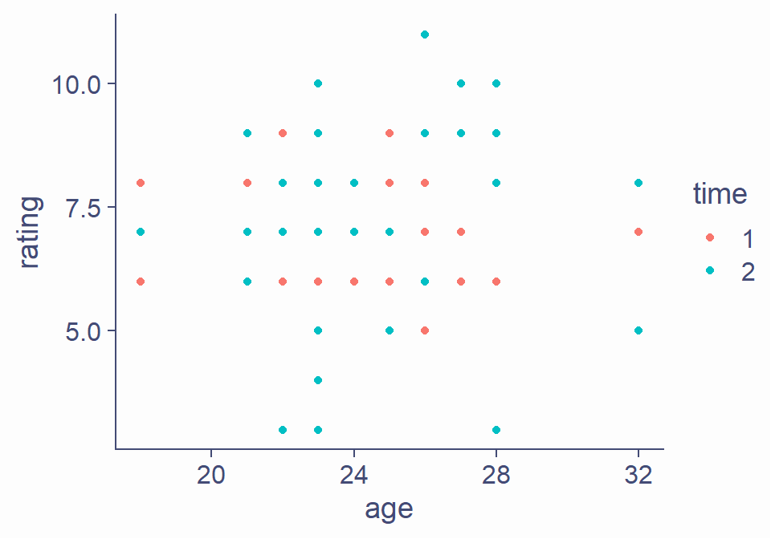

```r
df_long %>%
  mutate(time = factor(time)) %>%
  ggplot(aes(age, rating)) +
  geom_point(aes(colour = time))
```

In this case, it doesn’t really matter if you put the individual aesthetics inside of the `ggplot()` or the `geom_point()` function. The difference is that whatever you put into the topmost layer (`ggplot()`) will get passed on to all the subsequent geoms, while the aesthetic you give to a particular geom will only apply to it. To illustrate this point, let’s add a regression line:

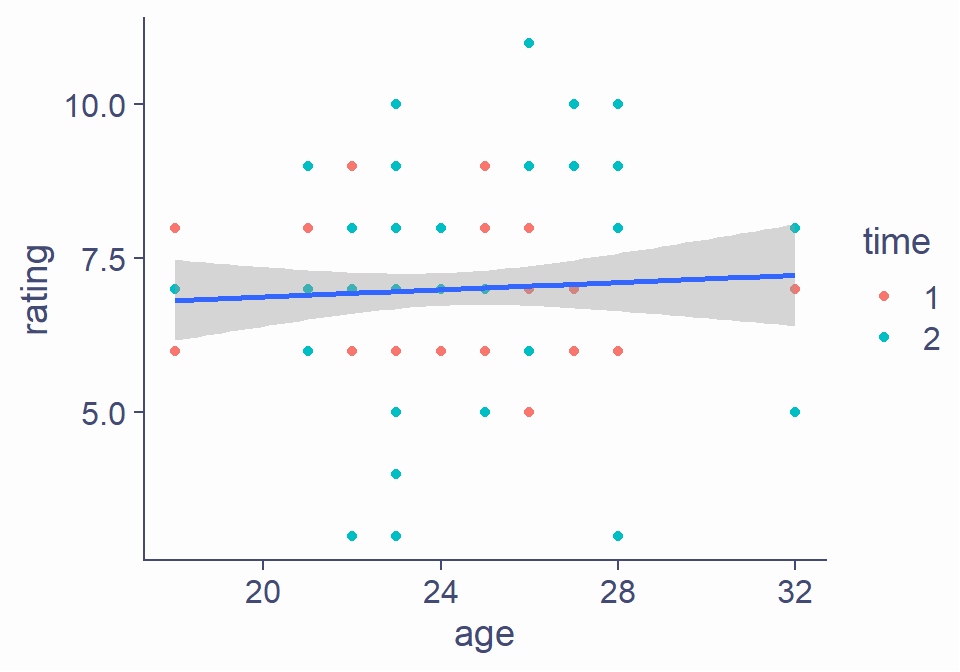

```r
df_long %>%
  mutate(time = factor(time)) %>%
  ggplot(aes(age, rating)) +
  geom_point(aes(colour = time)) + geom_smooth(method = "lm")
```

Since `colour = time` is given to `geom_point()`, it doesn’t impact `geom_smooth()` which only draws one line. If we want `geom_smooth` to draw one line per `time` point, we can just move the `colour =` argument to the topmost `ggplot()` layer:

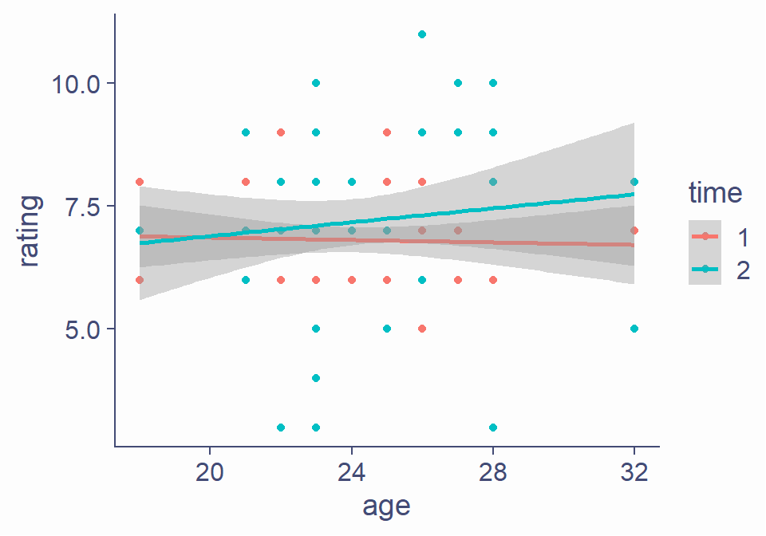

```r
df_long %>%
  mutate(time = factor(time)) %>%
  ggplot(aes(age, rating, color = time)) +
  geom_point() + geom_smooth(method = "lm")
```

Here is an example of a standard publication-ready grouped bar plot with error bars presenting a neat representation of a $2\times 2$ design. The data we’re plotting comes from the `df_long` data set we created at the bottom of the “Wide to long” section above.

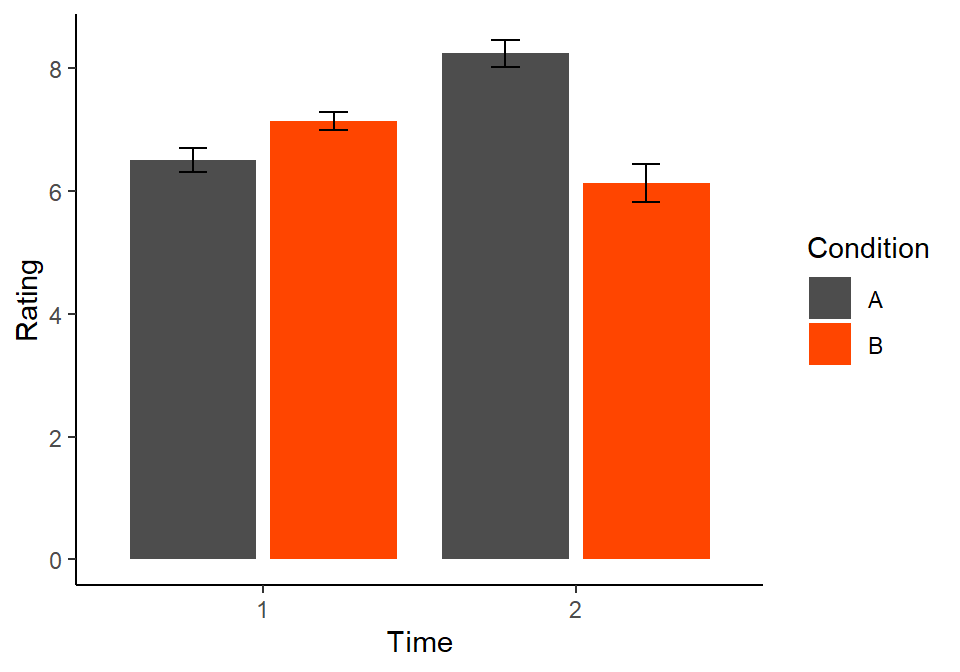

Recall that the data set looks like this:

```r
head(df_long)
# A tibble: 6 x 5
     id   age condition  time rating
  <int> <dbl> <fct>     <int>  <dbl>
1     1    21 A             1      8
2     1    21 A             2      9
3     1    21 B             1      7
4     1    21 B             2      6
5     2    26 A             1      7
6     2    26 A             2     11
```

Let’s walk through the creation of this plot step by step. First of all, we need to create the summary data used for the plot. We need the mean `rating` per `condition` per `time` which determines the heights of the bars. For the error bars, we need to calculate the standard error according to the formula:

$$SE = \frac{\sigma}{\sqrt{n}}$$

where $\sigma$ is the standard deviation and $n$ is the number of observations per each combination of `condition` and `time`.

```r
plot_data <- df_long %>% group_by(condition, time) %>%
  summarise(mean_rating = mean(rating),
            se = sd(rating)/sqrt(n())) # n() - function that counts number of cases

plot_data
# A tibble: 4 x 4
# Groups:   condition [2]
  condition  time mean_rating    se
  <fct>     <int>       <dbl> <dbl>
1 A             1        6.5  0.190
2 A             2        8.23 0.218
3 B             1        7.13 0.150
4 B             2        6.13 0.310
```

Currently the `time` column of `plot_data` is a numeric variable. Let’s change it to factor:

```r
plot_data$time <- factor(plot_data$time)
```

OK, that’s the preparation done. Let’s start building our plot, saving it into an object called `p`. The lowest layer will define the variables we’re plotting and specify grouping by `condition`:

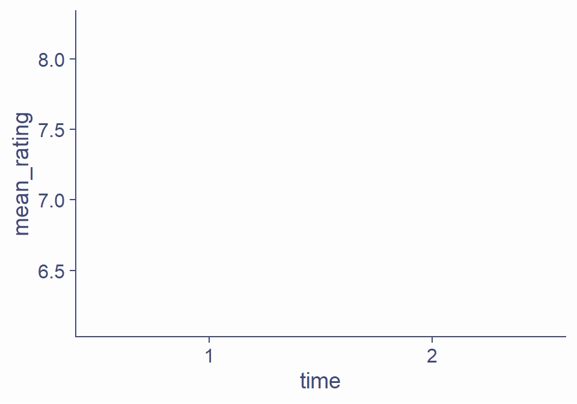

```r
p <- ggplot(plot_data, aes(x = time, y = mean_rating, fill = condition))

p
```

As you can see, this layer prepares the groundwork for the plot. The `fill =` argument is used to tell `ggplot()` that we want the bars to be filled using different colour by `condition`. Lets add the first plotting layer containing the bars and see what happens:

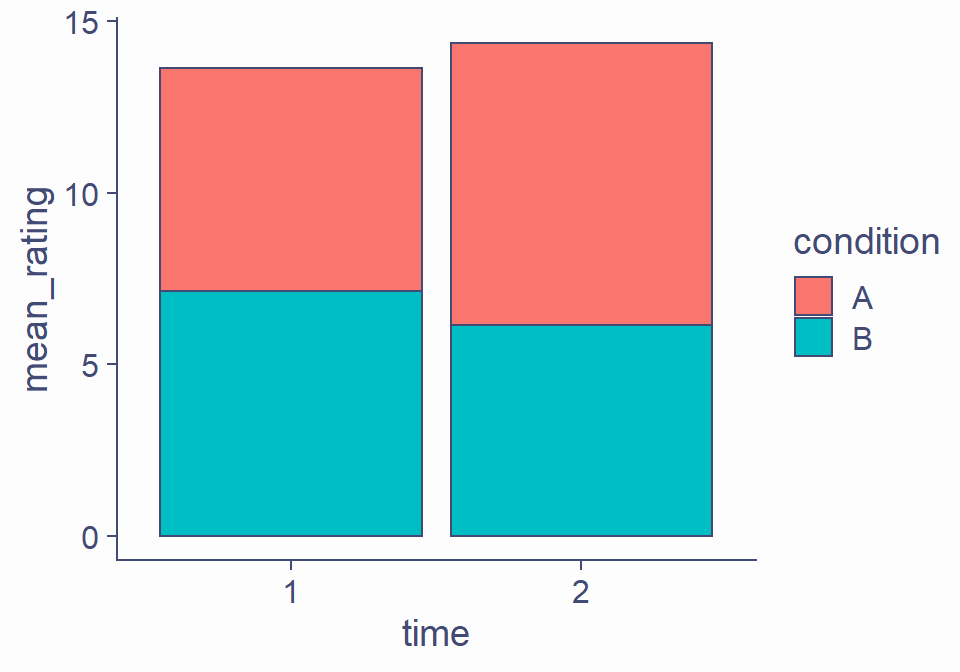

```r
p + geom_bar(stat = "identity")
```

Cool, we have ourselves a *stacked* bar chart. The `stat =` argument tells `R` what statistical transformation to perform on the data. If we were working with raw data, we could use the mean, for example. But since our `plot_data` data frame contains the means we want to plot, we need to tell `R` to plot these values (“identity”).

We also want the bars to be side by side rather than stacked atop one another. To do that, we specify the `position =` argument to the value `"dodge2"`. This will put them side by side but, as opposed to “dodge” will put a small gap between the unstacked bars (it just looks a bit nicer that way):

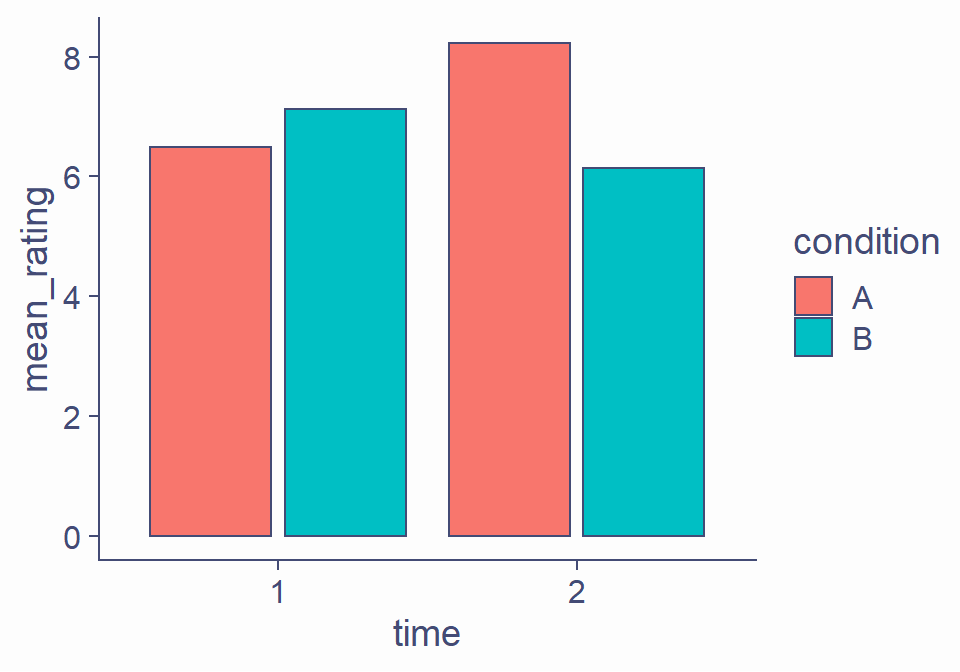

```r
p +  geom_bar(stat = "identity", position = "dodge2")
```

One thing that is not very pleasing about this plot that has to be dealt with in the `geom_bar()` function is the outlines of the bars. Let’s get rid of them by setting `color` to `NA`. We can now also add this layer to our `p` plot permanently by reassigning `p` the value of `p` plus the layer:

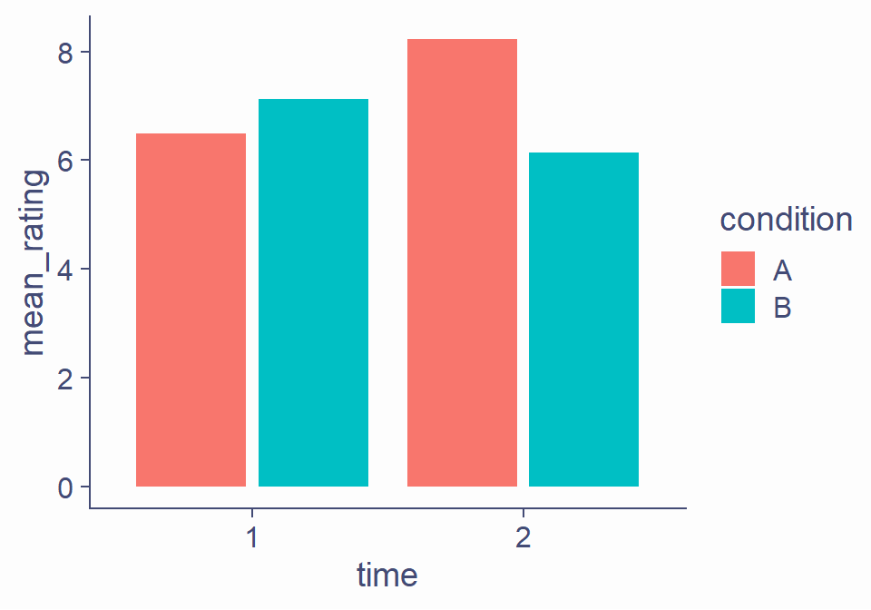

```r
p <- p + geom_bar(stat = "identity", position = "dodge2", color = NA)
p
```

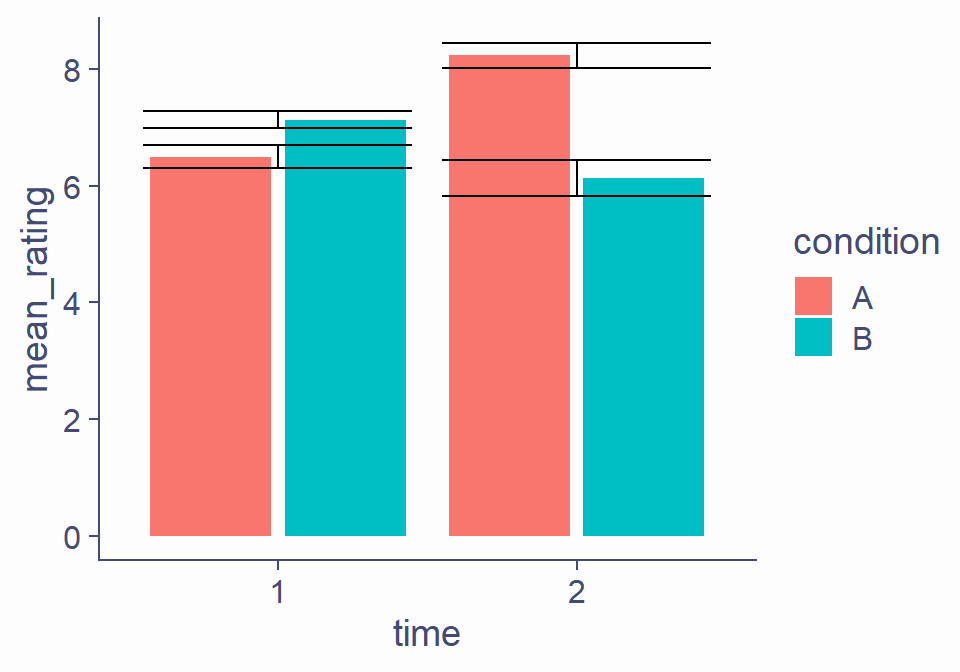

```r
p + geom_errorbar(aes(ymin = mean_rating - se, ymax = mean_rating + se))
```

Not quite perfect… The 4 error bars are drawn in 2 positions rather than in the middle of each corresponding bar. To get them in the right place, we need to specify the `position =` argument using the `position_dodge2()` function. The difference between `"dodge2"` and `position_dodge2()` is that the former is only a shorthand for the latter and it doesn’t allow us to change the default settings of the function. However, we don’t just want to put the error bars in the right place, we also want them to be a little thinner. To do that, we can say, that 80% of the space they now occupy should be just padding, thereby shrinking the width of the error bars:

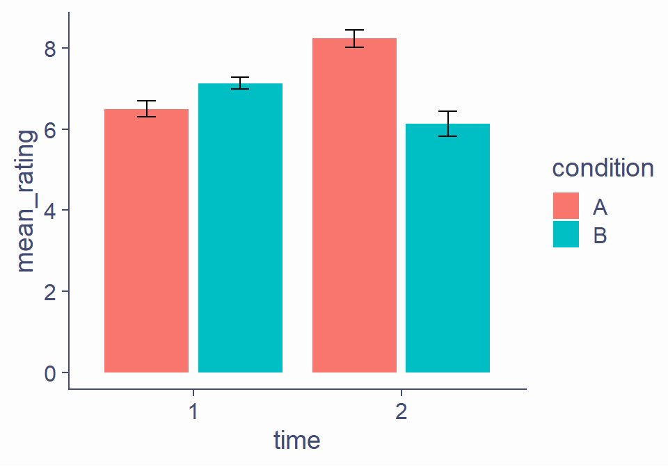

```r
p <- p + geom_errorbar(aes(ymin = mean_rating - se, ymax = mean_rating + se),
                       position = position_dodge2(padding = .8))
p
```

Much better. In fact, this is all the hard work done, the rest is just cosmetics. For instance, we can change the axis labels to make them look better:

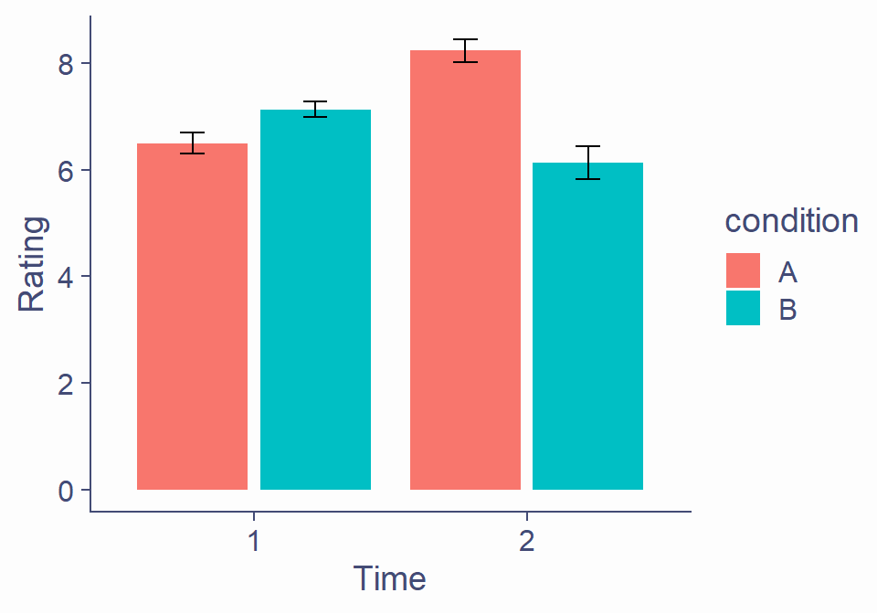

```r
p <- p + labs(x = "Time", y = "Rating")

p
```

Next, we can manually change the colours and the title of the legend like this:

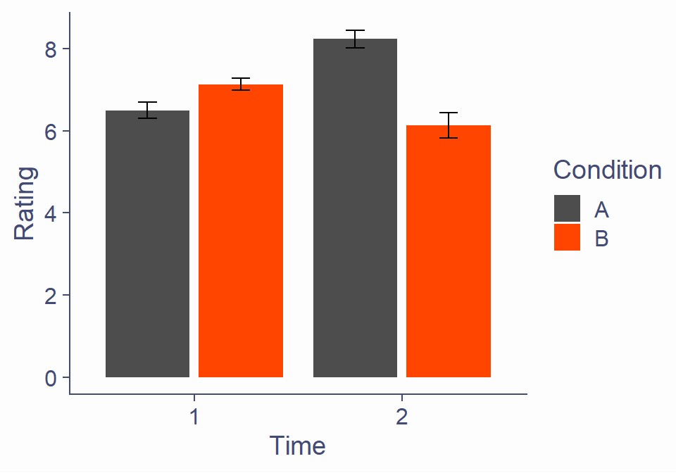

```r
p <- p + scale_fill_manual(values = c("grey30", "orangered"), name = "Condition")

p
```

And finally, we can give the plot a bit more of a classic look using `theme_classic()` (other themes are available and you can even create your own):

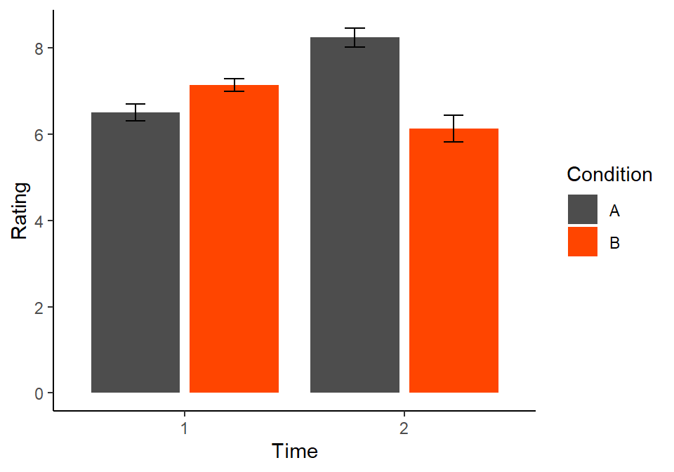

```r
p <- p + theme_classic()
p
```

If we now want to, we can export the plot as a .png file using the `ggsave()` function.

```r
ggsave("pretty_plot.png", p)
```

Because `ggplot2` is designed to work well with the rest of `tidyverse`, we can create the whole plot including the data for it in a single long pipeline starting with `df_long` (or even `my_data`, if you want):

```r
df_long %>%
  group_by(condition, time) %>%
  summarise(mean_rating = mean(rating),
            se = sd(rating)/sqrt(n())) %>%
  mutate(time = as.factor(time)) %>%
  ggplot(aes(x = time, y = mean_rating, fill = condition)) +
  geom_bar(stat = "identity", position = "dodge2", color = NA) +
  geom_errorbar(aes(ymin = mean_rating - se, ymax = mean_rating + se),
                position = position_dodge2(padding = .8)) +
  labs(x = "Time", y = "Rating") +
  scale_fill_manual(values = c("grey30", "orangered"), name = "Condition") +
  theme_classic()
```

An interesting thing to point out about `ggplot()` is that the layers are literally built one on top of another and they are not transparent. So, if you want the error bars to be sticking out of the columns without the lower halves of the bars visible, you can first build the `geom_errorbar()` layer and put the `geom_bar()` layer on top of it:

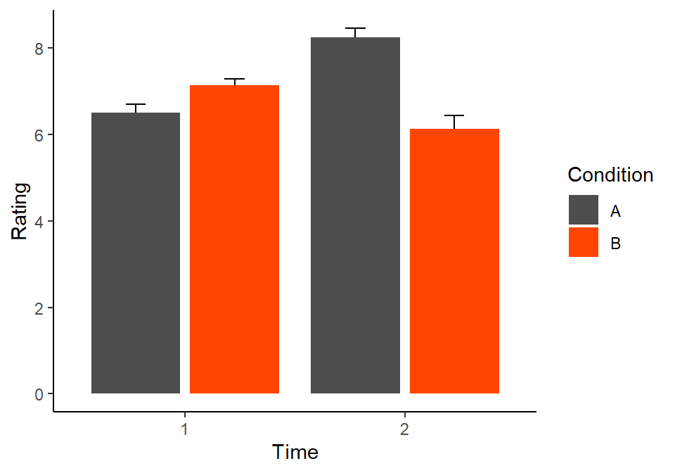

```r
plot_data %>%
  ggplot(aes(x = time, y = mean_rating, fill = condition)) +
  geom_errorbar(aes(ymin = mean_rating - se, ymax = mean_rating + se),
                position = position_dodge2(padding = .8)) +
  geom_bar(stat = "identity", position = "dodge2", color = NA) +
  labs(x = "Time", y = "Rating") +
  scale_fill_manual(values = c("grey30", "orangered"), name = "Condition") +
  theme_classic()
```

The logic behind building `ggplot()` graphs should now start making sense. Admittedly, it takes a little practice and a lot of online resources to feel reasonably confident with the package but once you get there, you will be able to create really pretty plots of arbitrary level of complexity. A good resource to refer to is the `ggplot2` [website](https://ggplot2.tidyverse.org/), where you can find all the other geoms we don’t have the space to cover along with examples.

# Useful tips

Following the principles detailed above is guaranteed to make you a better programmer so we hope you will stick to them. To help you along the way just that tiny bit more, here are a few additional tips.

## Break it down

Maybe you find yourself struggling with a task and turn to StackOverflow for help. Maybe you manage to find a ready-made answer to your problem or maybe some helpful soul writes one just for you. And maybe it works but you don’t quite understand why.

These things happen and sometimes a line of code can appear quite obscure. Take for example:

```r
for (i in 1:10) eval(parse(text = paste0(
  "df_", i, " <- as.data.frame(matrix(rnorm(100 * ", i ,", 0, ", i, "), ncol = i))")))
```

When faced with a bit of code like this, it is generally a good idea to try to reverse-engineer it. Let’s give it a go.

First, we can see that this is a `for` loop that repeats itself 10 times: it starts by assigning the value of `1` to the iterator object `i`, then executes the code, increments `i` by 1 and repeats until `i == 10`. So to look what the code inside the loop does, we need to set `i` to some value (`1` is a reasonable choice).

```r
i <- 1
```

Now, let’s start by running the code *from the innermost command outwards*:

```r
paste0("df_", i, " <- as.data.frame(matrix(rnorm(100 * ", i ,", 0, ", i, "), ncol = i))")
[1] "df_1 <- as.data.frame(matrix(rnorm(100 * 1, 0, 1), ncol = i))"
```

Right, so the first command created a character string that looks like a command. Let’s break it down even further:

```r
rnorm(100 * 1, 0, 1)
  [1]  0.060921227 -0.823491629  1.829730485 -1.429916216  0.254137143 -2.939773695  0.002415809  0.509665571
  [9] -1.084720001  0.704832977  0.330976350  0.976327473 -0.843339880 -0.970579905 -1.771531349 -0.322470342
 [17] -1.338800742  0.688156028  0.071280652  2.189752359 -1.157707599  1.181688064 -0.527368362 -1.456628011
 [25]  0.572967370 -1.433377705 -1.055185019 -0.733111877  0.210907264 -0.998920727  1.077850323 -1.198974383
 [33]  0.216637035  0.143087030 -1.065750091 -0.428623411 -0.656179477  0.959394327  1.556052636 -1.040796434
 [41]  0.930572409 -0.075445931 -1.967195349 -0.755903643  0.461149161  0.145106631 -2.442311321  0.580318685
 [49]  0.655051998 -0.304508837 -0.707568233  1.971572014 -0.089998681 -0.014017252 -1.123456937 -1.344130123
 [57] -1.523155771 -0.421968210  1.360924464  1.753794845  1.568364734  1.296755570 -0.237596251 -1.224150136
 [65] -0.327812680 -2.412450276 -0.313792873  1.659878705  0.130953101  1.095888683  0.489340957 -0.778910295
 [73]  1.743559353 -0.078387285 -0.975553793  0.070659825 -1.518599529  0.863779033  0.501568385 -0.354781330
 [81] -0.488428888  0.936293947 -1.062408386 -0.983820872  0.424247877 -0.451313481  0.925084797 -0.198620810
 [89]  1.194851017  0.495544705 -2.245152574 -1.335371360  1.282775206  0.690795904 -0.967062668 -1.345793685
 [97]  1.033665389 -0.811776460  1.801725479  1.771541960
```

OK, this is easy. The first bit generates $100 \times i$ random numbers with a mean of zero and a standard deviation of *i*. Let’s move one layer out:

```r
# printout truncated to first 10 lines
matrix(rnorm(100 * 1, 0, 1), ncol = i)
              [,1]
  [1,] -1.45469137
  [2,] -0.84565431
  [3,] -1.25047966
  [4,]  0.66728807
  [5,] -1.29076969
  [6,] -2.03500354
  [7,]  2.02134699
  [8,]  1.00597349
  [9,]  0.81712360
 [10,] -0.66398828
 [ reached getOption("max.print") -- omitted 90 rows ]
```

This command put those numbers into a `matrix` with 100 rows and *i* columns. Next:

```r
df_1 <- as.data.frame(matrix(rnorm(100 * 1, 0, 1), ncol = i))
```

This line converts the matrix into a `data.frame` and stored it in an object called “`df_i`”. Remember, `i` takes values of 1-10, increasingly each time the loop is repeated.

All good thus far but why is the command a character string (in “quotes”) What is that good for? Well, turns out that the `parse()` function can take a string with a valid `R` code inside and turn it to an `expression`:

```r
parse(text = paste0("df_", i, " <- as.data.frame(matrix(rnorm(100 * ",
                    i ,", 0, ", i, "), ncol = i))"))
expression(df_1 <- as.data.frame(matrix(rnorm(100 * 1, 0, 1), ncol = i)))
```

This expression can be then evaluated using the `eval()` function:

```r
eval(parse(text = paste0(
  "df_", i, " <- as.data.frame(matrix(rnorm(100 * ", i , ", 0, ", i, "), ncol = i))")))

# printout truncated
df_1
           V1
1   1.1936917
2  -0.1163955
3   0.5248586
4   0.2144215
5  -0.1344495
6   0.1685091
7   0.9647328
8   0.4087789
9  -0.4664382
10 -2.2397830
 [ reached 'max' / getOption("max.print") -- omitted 90 rows ]
```

So what the entire loop does is create 10 data frames named `df_1` to `df_10`, each containing 100 rows and a different number of columns (1 for `df_1`, 6 for `df_6` *etc.*) with random numbers. Moreover, each `data.frame` contains random numbers with different standard deviations.

And so, just like that, with a single line of code we can create 10 (or more!) different `R` objects with different properties. Cool, isn’t it? Hope this example demonstrates how, using systematic reverse-engineering, you can come to understand even a daunting-looking code with functions you haven’t seen before.

## Handy functions that return logicals

Finally, here are some useful functions with which you might want to familiarise yourself. They will make cleaning your data much easier.

- `==`, takes a `vector`, `matrix`, or a `data.frame` and compares every element thereof to **a single** value. Returns a `logical vector` with `TRUE` for elements that are *equal to* the compared value and `FALSE` otherwise. Comparing `NA` returns `NA`.

  ```r
  c(1:5, NA) == c(100, 2, 2, 8, 5, 9)
  [1] FALSE  TRUE FALSE FALSE  TRUE    NA
  ```

- `<`, same as `==`, but `TRUE` is returned if element is *less than* the compared value.
- `>`, same as `==`, but `TRUE` is returned if element is *greater than* the compared value.
- `<=`, same as `==`, but `TRUE` is returned if element is *less than or equal to* the compared value. In other words, it is a negation of (complementary operation to) `>`.
- `>=`, same as `==`, but `TRUE` is returned if element is *greater than or equal to* the compared value. Negation of `<`.
- `%in%`, same as `==`, but can take a `vector` on the right hand side. Each element of the `vector`/`matrix`/`data.frame` to the left is compared to each element of the vector to the right. For example:

  ```r
  c(1:5, NA) %in% c(100, 4, 2, 8)
  [1] FALSE  TRUE FALSE  TRUE FALSE FALSE
  ```

- all functions that begin with ‘`is`’, *e.g.*:
  - `is.na()`, takes a `vector`, `matrix`, or a `data.frame` and returns a `logical vector` with `TRUE` if given element is an `NA` and `FALSE` otherwise.
  - `is.numeric()`, takes any object and returns `TRUE` if it is a numeric vector and `FALSE` otherwise.
  - `is.factor()`, `is.matrix()`, `is.data.frame()`, `is.list()`, same as `is.numeric()` but return `TRUE` if the object provided is a `factor`, `matrix`, `data.frame`, or `list`, respectively.
  - `isTRUE()`, returns *a single* `TRUE` if the expression provided evaluates to `TRUE` and *a single* `FALSE` otherwise. Only `isTRUE(TRUE)` returns `TRUE`. `isTRUE(FALSE)`, `isTRUE(c(TRUE, TRUE))` and anything else returns `FALSE`. Works with `NA`s so can be useful for combining with logical operators that return `NA` when comparing missing values. For example

  ```r
  NA > 4
  [1] NA
  isTRUE(NA > 4)
  [1] FALSE
  ```

- `any()`, takes a logical vector and returns `TRUE` if **any** of its elements equals `TRUE`, and `FALSE` otherwise, *e.g.,* `any(1:5` `> 4)` returns `TRUE`.
- `all()`, like `any()` but returns `TRUE` only if **all** of the elements of the vector provided are `TRUE`.
- `all.equal()`, takes two objects and returns `TRUE` if they are identical and a *vector of all discrepancies* otherwise. Sensitive to attributes so `all.equal(1:5, factor(1:5))` does not return `TRUE`. Good to use along with `isTRUE()`!

  ```r
  all.equal(df, df)
  [1] TRUE
  all.equal(df, my_list)
   [1] "Names: 3 string mismatches"
   [2] "Attributes: < names for target but not for current >"
   [3] "Attributes: < Length mismatch: comparison on first 0 components >"
   [4] "Length mismatch: comparison on first 3 components"
   [5] "Component 1: 'current' is not a factor"
   [6] "Component 2: Modes: numeric, character"
   [7] "Component 2: Lengths: 10, 5"
   [8] "Component 2: target is numeric, current is character"
   [9] "Component 3: Modes: numeric, list"
  [10] "Component 3: Lengths: 10, 2"
   [ reached getOption("max.print") -- omitted 3 entries ]
  # use with isTRUE() if T/F desired
  isTRUE(all.equal(1:5, factor(1:5)))
  [1] FALSE
  ```

- `&`, “AND” takes two Booleans and returns `TRUE` if **both of them** are `TRUE`, `NA` if either is `NA`, and `FALSE` otherwise. Can be applied over two `logical vectors` of the *same length*:

  ```r
  c(T, T, F) & c(T, T, T)
  [1]  TRUE  TRUE FALSE
  ```

- `|`, “OR” is the same as `&` but returns `TRUE` if **either or both** of the two compared elements is `TRUE`.
- `xor()`, “exclusive OR” is same as above but returns `TRUE` only if **either** the first or the second, **but not both** of the two compared elements, is `TRUE`.

  ```r
  xor(c(T, F, F), c(T, F, T))
  [1] FALSE FALSE  TRUE
  ```

- `&&` and `||`, single-element versions of `&` and `|`. They only compare the first element of both of the vectors provided (*i.e.,* x[1] vs y[1]):

  ```r
  c(T, F, F) || c(T, F, T)
  [1] TRUE
  ```

- all of the above can be negated using the ‘`!`’ operator, *e.g.*:
  - `x != y`
  - `!x > y`
  - `!is.na(x)`
  - `!any(is.na(x))` is equivalent to `all(!is.na(x))`
  - `!(x & y)` is equivalent to `xor(x, y) | (!x & !y)`

# Jargon dictionary

**Argument.** Parameter that determines the behaviour of a function. Can be optional or required. *E.g.,* in `rnorm(n = 100, mean = 40, sd = 5)`, `n`, `mean`, and `sd`, are all arguments of the `rnorm` function.

**Character.** One of four vector classes (along with numeric, logical, and factor). Vector of this class contains quoted (`""`) alphanumeric elements. Maths cannot be calculated with character vectors.

**Class.** Basic property of an object, *e.g.,* numeric, character, list, data.frame, function.

**Command.** Combination of functions, objects, and arguments that, if grammatically and syntactically correct, serves as an instruction for the computer to perform an operation.

**Console.** Direct interface to the `R` interpreter. This is where commands get run and where output of operations is printed.

**Data frame.** Primary way of storing data sets. Square arrangement of elements where a single column can only contain elements of the same class. Sits between lists and matrices and can be subsetted using `$column_name`, `[[column index or name]]` or `[row, column]`.

**Data structure.** Grouping of elements, *e.g.,* vector, matrix, list.

**Element.** Constituent part of data structures (vectors, lists, data.frames…).

**Factor.** One of four vector classes (along with numeric, logical, and factor). Factors are used mainly for plotting and modelling nominal and ordinal variables. They are essentially integer variables with character labels superimposed on them.

**Function.** A chunk of code that takes some input values and based on them returns some object. Functions are always used with `()` after function name.

**Logical.** One of four vector classes (along with numeric, logical, and factor). Logical vectors only contain Boolean elements `TRUE` and `FALSE`.

**List.** A one-dimensional data structure that can contain as its elements any data structures (including lists, data.frames…) of any length and any class. Elements can be named and can be subsetted either using the `$` notation or `[[]]`.

**Matrix.** A square arrangement of elements of a single class. Has 2 dimensions: rows and columns. Can be subsetted using `[rows, columns]`.

**Numeric.** One of four vector classes (along with numeric, logical, and factor).

**Object.** Anything in `R`. :-) Contents of an object can be printed/accessed by calling its *unquoted* name (*i.e.,* with no `""`s).

**Operator.** A function in *infix* form, such as `+`, `<-`, `%in%`, or `%>%`.

**Output.** Object returned bu a function.

**Print.** To output the content of an object into the console.

**Script.** A text file including a sequence of commands written in order to achieve some goal, *e.g.,* data processing/analysis. It should be written in a way that allows it to be evaluated (run) line by line without errors.

**String.** Element of a character vector, such as `"A"`, `"test_score_1"`, or `"&*$£(*)"`. Always surrounded by quotes. Strings are not interpreted by `R`: `"mean"` does not do anything, it is just a string, not the `mean()` function.

**Variable.** Colloquial term for either a vector or a column of a data frame.

**Vector.** Most basic data structure. One-dimensional arrangement of elements of the same class. Only has length and can be subsetted using `[]`.

[^1]: An important insight immortalised by Newton Crosby in the 1986 cult movie [Short Circuit](http://www.imdb.com/title/tt0091949/?ref_=ttqt_qt_tt): “It’s a machine, Schroeder. It doesn’t get pissed off. It doesn’t get happy, it doesn’t get sad, it doesn’t laugh at your jokes. *It just runs programs.*”
[^2]: Open Science Collaboration. (2015). Estimating the reproducibility of psychological science. *Science, 349*(6251), aac4716.